# Ein 3D-CNN für Ziffern-Volumen — trainieren und erklären

## Worum geht es in diesem Notebook?

Wir trainieren ein **dreidimensionales Convolutional Neural Network** (3D-CNN) darauf, handgeschriebene Ziffern zu erkennen — allerdings nicht als flaches Bild, sondern als **Würfel aus 16×16×16 Volumenpixeln** („Voxel"). Danach stellen wir dem fertigen Netz die entscheidende Frage:

> **„Welche Voxel haben dich zu dieser Entscheidung gebracht?"**

Die Antwort kommt als **Relevanzkarte** (Heatmap): jedem der 4096 Eingabe-Voxel wird eine Zahl zugewiesen — *wie stark hat dieses Voxel für (rot) oder gegen (blau) die erklärte Ziffer gesprochen?* Das Verfahren dazu heißt **Layer-wise Relevance Propagation (LRP)**.

## Der größere Kontext: warum überhaupt XAI?

Ein neuronales Netz lernt seine Regeln aus Daten und versteckt sie in Millionen von Gewichten. Der Kernsatz der XAI-Community („eXplainable AI") lautet:

> *„Just because a model is right doesn't mean it got there for the right reason."*

Ein Netz könnte eine Ziffer auch an einem Bildrand-Artefakt, an der Schreibdicke oder an der Orientierung im Raum erkennen. Solche Fälle heißen **Clever-Hans-Prädiktoren** (nach dem „rechnenden Pferd", das in Wahrheit die Körpersprache seines Besitzers las). Erklärungsverfahren wie LRP machen so etwas sichtbar.

## Warum ausgerechnet 3D und ausgerechnet Ziffern?

Dieses Notebook ist ein **Trainingslager für medizinische Bildgebung**. MRT-, CT- und PET-Aufnahmen sind grundsätzlich Volumen, keine Bilder — und genau dafür sind die anderen Notebooks in diesem Repository gedacht (Hirnalter-Vorhersage, Demenz-Klassifikation). Nur ist ein Gehirnvolumen mit 256³ Voxeln unhandlich: das Training dauert Stunden, und **niemand weiß, was die richtige Antwort wäre**.

3D-MNIST löst beide Probleme:

| Eigenschaft | Vorteil |
| --- | --- |
| 16³ = 4096 Voxel statt Millionen | Training in Minuten statt Tagen, läuft auf einer Laptop-GPU |
| Wir wissen, was drin ist | Zeigt die Heatmap auf leeren Raum, ist etwas faul |
| Zehn klar getrennte Klassen | Man kann fragen: „warum *diese* Ziffer und nicht jene?" |
| Dieselbe `Conv3D`-Maschinerie wie beim MRT | Alles hier Gelernte überträgt sich 1:1 |

Kurz: **Wenn die Erklärungs-Pipeline hier nicht funktioniert, funktioniert sie beim Gehirn erst recht nicht.**

## Der Unterschied zwischen 2D und 3D in einem Bild

```
  2D-Bild (klassisches MNIST)          3D-Volumen (dieses Notebook)
  ┌───────────────┐                    ┌───────────────┐
  │               │                    │  ╱───────────╲│   16 Schichten
  │      ███      │  28 × 28 Pixel     │ ╱   ███  ╱   ╱│   hintereinander
  │       █       │  = 784 Zahlen      │╱    █   ╱   ╱ │   16 × 16 × 16
  │      ███      │                    │    ███ ╱   ╱  │   = 4096 Zahlen
  └───────────────┘                    └───────────────┘
  Filter: 3 × 3 = 9 Gewichte           Filter: 3 × 3 × 3 = 27 Gewichte
```

Ein 3D-Filter „sieht" also nicht nur nach links/rechts/oben/unten, sondern auch **nach vorn und hinten**. Das ist der ganze konzeptionelle Unterschied — und gleichzeitig der Grund, warum 3D-Netze so viel teurer sind.

## LRP in drei Sätzen

1. **Observe** — ein normaler Vorwärtsdurchlauf liefert die Vorhersage.
2. **Redistribute** — der Ausgabewert der Zielklasse wird Schicht für Schicht **rückwärts** verteilt, jeweils proportional dazu, wie stark ein Neuron zur Aktivierung des nachfolgenden beigetragen hat.
3. **Reveal** — am Ende liegt die gesamte „Relevanz" auf den Eingabe-Voxeln und ergibt die Heatmap.

Die zentrale Eigenschaft ist die **Erhaltung (Conservation)**: LRP erzeugt und vernichtet keine Relevanz, es verteilt sie nur um.

$$\sum_j R_j \;=\; \sum_k R_k \qquad \text{für jede Schicht}$$

Wichtig zu verinnerlichen: **Relevanz ist nicht dasselbe wie Aktivierung.** Ein schwach aktiviertes Neuron kann sehr relevant sein, wenn genau es den Ausschlag gab.

## Ablauf dieses Notebooks

```
  ┌─ Teil A: Modell bauen ───────────────────────────────────────────────┐
  │  10.000 Volumen ──► [3D-CNN, 3,5 Mio. Parameter] ──► 10 Wahrscheinl. │
  │  (Abschnitte 1–5)                                                    │
  └──────────────────────────────────────────────────────────────────────┘
                                   │
  ┌─ Teil B: Modell erklären ──────▼─────────────────────────────────────┐
  │  1 Volumen (eine „3") ──► LRP rückwärts ──► 10 Relevanz-Volumen      │
  │  (Abschnitte 6–8)          einmal je Zielklasse 0…9                  │
  └──────────────────────────────────────────────────────────────────────┘
                                   │
  ┌─ Teil C: Interaktiv in 3D ─────▼─────────────────────────────────────┐
  │  Punktwolke: Eingabe  ‖  Punktwolke: Relevanz  (drehbar)             │
  │  (Abschnitte 9–11)                                                   │
  └──────────────────────────────────────────────────────────────────────┘
```

## Inhaltsverzeichnis

| # | Abschnitt | Inhalt |
| --- | --- | --- |
| 1 | Die Daten: 3D-MNIST laden und ansehen | HDF5, Voxelgitter, One-Hot, Slice-Ansicht |
| 2 | Das 3D-CNN: Architektur | `Conv3D`, BatchNorm, Pooling, 3,5 Mio. Parameter |
| 3 | Exkurs: Farbskalen richtig lesen | warum `jet` für Heatmaps ungeeignet ist |
| 4 | Training: Verlust, Optimierer, Callbacks | Cross-Entropy, Adam, `ReduceLROnPlateau` |
| 5 | Das Modell: laden oder trainieren | `.keras`-Format, Trennung Training / Analyse |
| 6 | LRP: zehn Erklärungen für ein Volumen | Regelstrategie, Relevanzsummen vs. Logits |
| 7 | Die Slice-Galerie: 10 Klassen × 16 Schichten | die zentrale Abbildung, Rot/Blau lesen |
| 8 | Die Differenzmatrix | wie klassenspezifisch sind die Erklärungen wirklich? |
| 9 | Das Volumen als 3D-Punktwolke | Plotly, Schwellwert, Rendering-Hinweis |
| 10 | Eine 3D-Zahl rein → Vorhersage raus | die Minimal-Pipeline in fünf Zeilen |
| 11 | Input und Erklärung nebeneinander in 3D | die anschaulichste Darstellung |
| 12 | Anhang: Rohdaten-Zelle | Sandbox-Zelle, ohne Wirkung auf das Notebook |
| 13 | Fazit: was man mitnehmen sollte | Stärken, Grenzen, Fallstricke |

**Hintergrunddokument im Repo:** `doc/LRP_Fraunhofer_HHI_Video_Zusammenfassung.md` — die LRP-Theorie in Worten, inklusive der Rot/Blau-Semantik.

**Verwandtes Notebook:** `Explain_2D_VGG_predictions` vergleicht die einzelnen LRP-Regeln (LRP-0, ε, αβ, flat, Composite) systematisch am 2D-Fall. Wer die Regelwahl in Abschnitt 6 genauer verstehen will, findet dort die Herleitungen.

## 1. Die Daten: 3D-MNIST laden und ansehen

↑ Inhaltsverzeichnis

### Was passiert hier?

Fünf Schritte in einer Zelle:

1. **Repository finden.** `find_repo_root()` läuft vom aktuellen Arbeitsverzeichnis nach oben, bis es `pyproject.toml` oder den Ordner `explainability/` sieht, und hängt das Ergebnis an `sys.path`. Erst dadurch ist später `from explainability import LRP` importierbar — egal, aus welchem Ordner der Jupyter-Kernel gestartet wurde.
2. **HDF5-Datei öffnen.** `full_dataset_vectors.h5` ist der [3D-MNIST-Datensatz von Kaggle](https://www.kaggle.com/daavoo/3d-mnist). HDF5 ist das Standardformat für große wissenschaftliche Arrays; `h5py` liest es wie ein `dict`.
3. **Umformen zu Volumen.** In der Datei liegt jedes Beispiel als **flacher Vektor mit 4096 Zahlen**. `np.reshape(..., (-1, 16, 16, 16, 1))` faltet ihn zum Würfel auf:

   $$4096 \;=\; 16 \times 16 \times 16$$

   Die `-1` heißt „so viele Beispiele, wie eben da sind", die abschließende `1` ist die **Kanaldimension** (bei einem Farbbild stünde dort 3 für RGB; hier gibt es nur einen Graustufen-Kanal). Keras erwartet für `Conv3D` immer genau diese fünf Achsen: `(Batch, Tiefe, Höhe, Breite, Kanäle)`.
4. **Spiegeln.** `train_X[:, ::-1, :, :]` dreht die **Achse 1** um. Reiner Anzeige-Kosmetik-Schritt: `plt.imshow` zeichnet Zeile 0 ganz oben, das Voxelgitter zählt aber von unten. Ohne diese Zeile stünden alle Ziffern auf dem Kopf. Weil die Spiegelung auf **Trainings- und Testdaten gleich** angewandt wird, ändert sie am Lernproblem nichts.
5. **One-Hot-Kodierung.** Aus dem Label `3` wird der Vektor

   $$\mathbf{y} = (0,0,0,\mathbf{1},0,0,0,0,0,0)$$

   Warum? Die Verlustfunktion `categorical_crossentropy` vergleicht zwei Wahrscheinlichkeitsverteilungen. Ohne One-Hot würde das Netz die Labels als **Zahlen** deuten und „7 ist größer als 3" lernen — Unsinn, denn Ziffern sind Kategorien, keine Messwerte.

### Wie sehen die Daten konkret aus?

| Größe | Wert |
| --- | --- |
| Trainingsbeispiele | 10.000 |
| Testbeispiele | 2.000 |
| Form pro Beispiel | (16, 16, 16, 1) = 4096 Voxel |
| Wertebereich | 0,0 bis 1,0 (bereits normiert) |
| Belegte Voxel | im Schnitt rund **15 %** — die Volumen sind also sehr **dünn besetzt** |
| Klassenverteilung | 868 bis 1126 pro Ziffer, also näherungsweise ausgeglichen |

Die Volumen entstehen, indem die 2D-MNIST-Ziffer zu einer **Punktwolke** gemacht, im Raum zufällig **rotiert** und wieder auf ein 16³-Gitter gerastert wird. Deshalb liegt dieselbe Ziffer in jedem Beispiel in einer anderen Lage — das Netz muss **rotationsrobust** werden, was die Aufgabe deutlich schwerer macht als klassisches 2D-MNIST.

### Was man auf den Abbildungen sieht

Die Schleife zeigt die ersten fünf Trainingsbeispiele. Jede Abbildung ist ein **4×4-Raster mit den 16 Schnittebenen** eines einzigen Volumens; die Zahl über dem Raster ist das wahre Label. Man blättert also durch den Würfel wie durch die Schichten eines MRT-Scans (`cmap='Greys'`: schwarz = Voxel belegt, weiß = leer).

| Beispiel | Label | Was zu sehen ist |
| --- | --- | --- |
| 0 | 5 | Eine klare, leicht schräg stehende **5** wiederholt sich über ~7 Schichten. Die Ziffer liegt fast **parallel** zur Schnittebene. |
| 1 | 5 | Nur kleine, kompakte Flecken pro Schicht. Dieselbe Ziffer steht hier fast **senkrecht** zur Schnittebene — wir sehen sie „von der Kante". |
| 2 | 0 | Ein deutlicher **Ring**, ebenfalls schichtweise wiederholt. |
| 3 | 0 | Dieselbe Null, aber schräg gekippt: pro Schicht nur noch kleine Ringfragmente. |
| 4 | 4 | Eine gut lesbare **4**, wieder nahezu parallel zur Schnittebene. |

### Interpretation

Die fünf Abbildungen sind **die wichtigste Lektion dieses Abschnitts**: Beispiel 0 und Beispiel 1 tragen dasselbe Label „5", sehen als Schnittbilder aber **völlig unterschiedlich** aus. Beispiel 1 würde kein Mensch als Fünf erkennen — die Information steckt nicht in einer einzelnen Schicht, sondern **erst in ihrer Kombination**.

Genau deshalb braucht man hier `Conv3D` und nicht `Conv2D`: Ein 2D-Filter sieht immer nur eine Schicht und hätte bei Beispiel 1 keine Chance. Ein 3D-Filter sieht 3×3×**3** Voxel und kann die Ziffer über die Tiefe hinweg zusammensetzen.

### Einordnung

Das ist exakt dieselbe Situation wie bei einem MRT: Ein einzelner axialer Schnitt zeigt einen Hippocampus nur als kleinen grauen Fleck; seine Form ergibt sich erst über 20 Schichten. Wer medizinische Volumen mit 2D-Netzen scheibenweise verarbeitet (was durchaus üblich ist), wirft diese Information weg — und muss sie durch andere Tricks wieder hereinholen.

```
Notebook-Name ist: Train_and_explain_3D_mnist_model
Zielordner ist: /mnt/users/andreasre/git-repos/keras-explainability/output/notebooks/Train_and_explain_3D_mnist_model
```

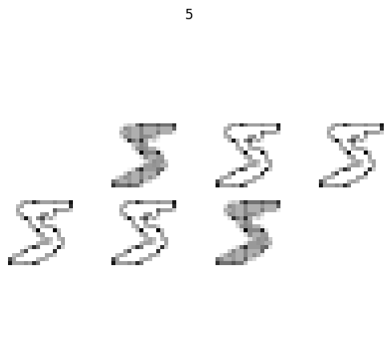

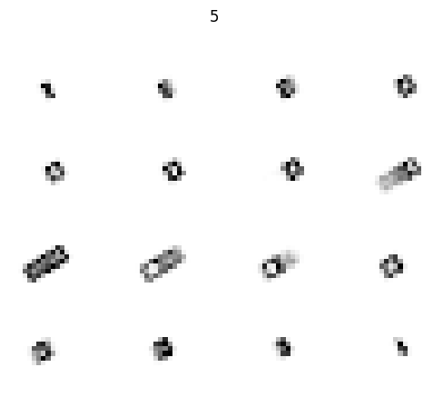

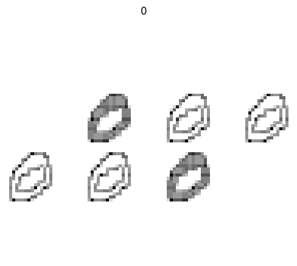

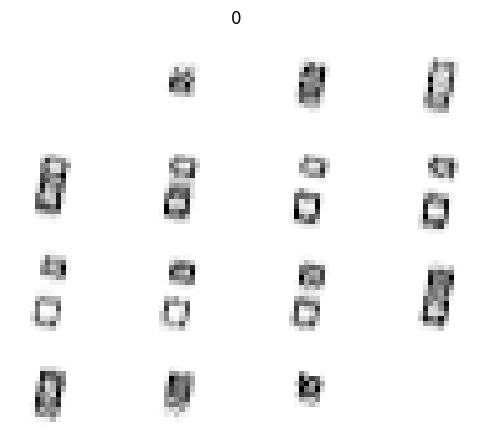

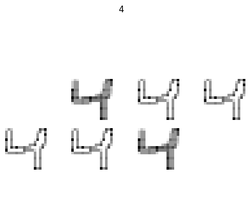

```python
import sys
import os
from pathlib import Path


def find_repo_root() -> Path:
    p = Path.cwd().resolve()
    for candidate in [p, *p.parents]:
        if (candidate / "pyproject.toml").exists() or (candidate / "explainability").is_dir():
            return candidate
    return p


repo_root = find_repo_root()
if str(repo_root) not in sys.path:
    sys.path.insert(0, str(repo_root))

import h5py
import matplotlib.pyplot as plt
import numpy as np

import ipynbname


def _process_ancestors(pid: int, levels: int = 5) -> list[int]:
    pids = []
    for _ in range(levels):
        pids.append(pid)
        try:
            stat = Path(f"/proc/{pid}/stat").read_text()
            # Feld 4 von stat ist die PPID; der Prozessname in Feld 2 kann
            # Leerzeichen enthalten, deshalb erst hinter ")" trennen
            pid = int(stat[stat.rindex(")") + 1:].split()[1])
        except Exception:
            break
        if pid <= 1:
            break
    return pids


def find_notebook_name() -> str:
    """Ermittelt den Namen des laufenden Notebooks ohne .ipynb-Endung."""
    # 1. Interaktiv (JupyterLab, VS Code): ipynbname fragt den Jupyter-Server
    #    bzw. liest __vsc_ipynb_file__
    try:
        return ipynbname.name()
    except Exception:
        pass

    # 2. jupyter-server >= 2 stellt den Notebook-Pfad in die Kernel-Umgebung,
    #    papermill & Co. setzen __session__
    for candidate in (os.environ.get("JPY_SESSION_NAME"), globals().get("__session__")):
        if candidate and candidate.endswith(".ipynb"):
            return Path(candidate).stem

    # 3. Als reines Skript ausgeführt (python notebooks/py_files/<name>.py)
    if "__file__" in globals():
        return Path(globals()["__file__"]).stem

    # 4. Unter nbconvert/quarto gibt es keine der obigen Quellen — dort steht der
    #    Notebook-Pfad aber in der Kommandozeile des aufrufenden Prozesses
    #    (JPY_PARENT_PID zeigt auf nbconvert, dessen Vorfahren auf make/quarto)
    start_pid = int(os.environ.get("JPY_PARENT_PID") or os.getppid())
    for pid in _process_ancestors(start_pid):
        try:
            args = Path(f"/proc/{pid}/cmdline").read_bytes().decode().split("\0")
        except Exception:
            continue
        for arg in args:
            if arg.endswith(".ipynb"):
                return Path(arg).stem

    raise RuntimeError(
        "Notebook-Name konnte nicht ermittelt werden — bitte NOTEBOOK_NAME setzen."
    )


notebook_name = os.environ.get("NOTEBOOK_NAME") or find_notebook_name()

target_dir = repo_root / "output" / "notebooks" / notebook_name
target_dir.mkdir(parents=True, exist_ok=True)

print(f"Notebook-Name ist: {notebook_name}")
print(f"Zielordner ist: {target_dir}")

data_path = repo_root / 'data' / '3d-mnist' / 'full_dataset_vectors.h5'

assert os.path.isfile(data_path), \
    'Download the 3d-mnist data from https://www.kaggle.com/daavoo/3d-mnist'

with h5py.File(data_path, 'r') as f:
    train_X = np.reshape(f["X_train"][:], (-1, 16, 16, 16, 1))
    train_y = f["y_train"][:]
    test_X = np.reshape(f["X_test"][:]  , (-1, 16, 16, 16, 1))
    test_y = f["y_test"][:]

train_X = train_X[:,::-1,:,:]
test_X = test_X[:,::-1,:,:]

def onehot(values: np.ndarray) -> np.ndarray:
    encoded = np.zeros((len(values), 10))

    for i in range(len(values)):
        encoded[i,values[i]] = 1

    return encoded

train_y = onehot(train_y)
test_y = onehot(test_y)

for i in range(5):
    fig, ax = plt.subplots(4, 4)
    fig.suptitle(str(np.argmax(train_y[i])))
    ax = ax.ravel()

    for j in range(16):
        ax[j].imshow(train_X[i,:,:,j], cmap='Greys')
        ax[j].axis('off')

    plt.show()
```

## 2. Das 3D-CNN: Architektur

↑ Inhaltsverzeichnis

### Was passiert hier?

Diese Zelle **baut** das Netz — sie trainiert noch nichts. Alle Gewichte sind danach zufällig initialisiert. Verwendet wird die **Functional API** von Keras: man reicht einen Tensor durch Schichten hindurch (`x = Schicht(...)(x)`) und übergibt am Ende Ein- und Ausgang an `Model`.

### Die vier Bausteine

**1. `Conv3D` — die Faltung.** Ein kleiner Würfel von Gewichten (hier immer 3×3×3 = **27 Gewichte**) wird über das gesamte Volumen geschoben. An jeder Position berechnet er

$$z \;=\; \sum_{u,v,w} a_{u,v,w}\, k_{u,v,w} \;+\; b$$

also eine gewichtete Summe der 27 Nachbarvoxel. Der Filter lernt dadurch ein **lokales Muster** (eine Kante, eine Ecke, eine Krümmung), und weil derselbe Filter überall angewandt wird, findet er dieses Muster **an jeder Stelle** des Volumens. Das ist das Prinzip der *Translationsinvarianz* und der Grund, warum CNNs mit so wenig Parametern auskommen.

`padding='SAME'` füllt den Rand mit Nullen auf, damit das Ausgabevolumen dieselbe Kantenlänge behält wie das Eingabevolumen.

**2. `BatchNormalization` — die Normalisierung.** Nach jeder Faltung werden die Werte über den Batch auf Mittelwert 0 und Varianz 1 gebracht und dann mit zwei gelernten Zahlen $\gamma, \beta$ wieder skaliert:

$$\hat a \;=\; \gamma\,\frac{a - \mu}{\sqrt{\sigma^2 + \varepsilon}} \;+\; \beta$$

Das stabilisiert das Training erheblich. **Für LRP ist das ein Sonderfall**: eine BatchNorm-Schicht ist zur Inferenzzeit eine affine Abbildung und lässt sich vollständig in die vorangehende Faltung hineinrechnen. Genau das tut `explainability/model/utils/fuse_batchnorm.py`, bevor die Relevanz rückwärts propagiert wird — deshalb tauchen die `normX`-Schichten in der LRP-Strategie (Abschnitt 6) gar nicht auf.

**3. `Activation('relu')` — die Nichtlinearität.** $\mathrm{ReLU}(x) = \max(0, x)$. Ohne sie wäre das ganze Netz nur eine einzige große lineare Abbildung, egal wie viele Schichten man stapelt.

**4. `MaxPooling3D((2,2,2))` — die Verkleinerung.** Aus jedem 2×2×2-Block wird nur das Maximum behalten. Die Kantenlänge halbiert sich, das **Volumen achtelt sich**. Nach drei Pooling-Stufen ist aus 16³ = 4096 nur noch 2³ = 8 geworden. Gleichzeitig wächst die Zahl der Filter (32 → 64 → 128 → 256): **räumliche Auflösung wird gegen semantischen Reichtum getauscht**.

### Der Aufbau im Überblick

| Block | Schichten | Ausgabeform | Was hier entsteht |
| --- | --- | --- | --- |
| Eingabe | `inputs` | (16, 16, 16, 1) | das rohe Voxelgitter |
| 1 | `conv1`, `conv2`, `pool1` | (8, 8, 8, 32) | Kanten und Oberflächen |
| 2 | `conv3`, `conv4`, `pool2` | (4, 4, 4, 64) | Krümmungen, Strichkreuzungen |
| 3 | `conv5`, `conv6`, `pool3` | (2, 2, 2, 128) | Ziffernteile (Bögen, Balken) |
| 4 | `conv7`, `conv8` | (2, 2, 2, 256) | ganze Ziffernkonzepte |
| Kopf | `pool4` (GlobalAvgPool) | (256,) | jedes Filter auf **eine Zahl** reduziert |
| Kopf | `dense` → `preds` | (10,) | zehn Wahrscheinlichkeiten |

`GlobalAveragePooling3D` mittelt jedes der 256 Filter über alle 8 Positionen. Das ersetzt das klassische `Flatten` und spart enorm Parameter: `Flatten` hätte 2·2·2·256 = 2048 Werte an die Dense-Schicht gegeben, so sind es nur 256. Es macht das Netz zusätzlich robust gegen Verschiebungen — allerdings **verwischt es auch die Ortsinformation**, was bei der Interpretation der Heatmaps in Abschnitt 7 noch eine Rolle spielt.

### Regularisierung: zwei Mechanismen gegen Auswendiglernen

Bei 10.000 Beispielen und 3,5 Mio. Parametern könnte das Netz den Trainingssatz schlicht auswendig lernen. Zwei Gegenmaßnahmen sind eingebaut:

- **L2-Regularisierung** (`weight_decay = 1e-3`): Zum Verlust wird $\lambda \sum_i w_i^2$ addiert. Große Gewichte werden also bestraft, das Netz bevorzugt „glatte" Lösungen.
- **Dropout** (`dropout = 0.3`): Beim Training werden 30 % der Neuronen zufällig auf 0 gesetzt. Das Netz kann sich nicht auf einzelne Neuronen verlassen. Bei der Inferenz ist Dropout inaktiv — deshalb stören die beiden `Dropout`-Schichten LRP nicht.

### Was die Ausgabe zeigt

`model.summary()` listet **34 Schichten** und meldet:

```
Total params:         3.519.680 (13,43 MB)
Trainable params:     3.517.740
Non-trainable params:     1.940
```

Die 1.940 nicht-trainierbaren Parameter sind die **laufenden Mittelwerte und Varianzen** der BatchNorm-Schichten: sie werden nicht durch Gradientenabstieg gelernt, sondern während des Trainings mitgezählt.

Zwei Zahlen lohnen einen zweiten Blick:

- `conv8` allein hat **1.769.728 Parameter** — die Hälfte des gesamten Netzes. Grund: $256 \times 256 \times 27 + 256 = 1.769.728$. Die Parameterzahl einer Faltung wächst mit dem **Produkt** von Eingangs- und Ausgangskanälen.
- `preds` hat nur **110 Parameter** ($10 \times 10 + 10$). Die eigentliche Entscheidung fällt also längst vorher; die letzte Schicht sortiert nur noch.

### Einordnung

Diese Architektur — abwechselnd zwei Faltungen und ein Pooling, Kanäle verdoppeln, GlobalAveragePooling am Ende — ist ein **VGG-artiges Standardmuster**. Genau dieselbe Struktur findet sich in den Hirn-Notebooks dieses Repositories, nur mit größerem Eingabevolumen und mehr Blöcken. Wer sie hier versteht, versteht sie dort auch.

```python
from tensorflow.keras import Model
from tensorflow.keras.layers import Activation, BatchNormalization, Conv3D, Dense, \
                                    Dropout, Flatten, \
                                    GlobalAveragePooling3D, Input, \
                                    MaxPooling3D
from tensorflow.keras.regularizers import l2

inputs = Input((16, 16, 16, 1), name='inputs')

x = inputs

kernel = (3, 3, 3)
dropout = 0.3
weight_decay = 1e-3
regularizer = l2(weight_decay)

x = Conv3D(32, kernel, padding='SAME', activation=None,
           kernel_regularizer=regularizer, name='conv1')(x)
x = BatchNormalization(name='norm1')(x)
x = Activation('relu')(x)
x = Conv3D(32, kernel, padding='SAME', activation=None,
           kernel_regularizer=regularizer, name='conv2')(x)
x = BatchNormalization(name='norm2')(x)
x = Activation('relu')(x)
x = MaxPooling3D((2, 2, 2), name='pool1')(x)
x = Conv3D(64, kernel, padding='SAME', activation=None,
           kernel_regularizer=regularizer, name='conv3')(x)
x = BatchNormalization(name='norm3')(x)
x = Activation('relu')(x)
x = Conv3D(64, kernel, padding='SAME', activation=None,
           kernel_regularizer=regularizer, name='conv4')(x)
x = BatchNormalization(name='norm4')(x)
x = Activation('relu')(x)
x = MaxPooling3D((2, 2, 2), name='pool2')(x)
x = Conv3D(128, kernel, padding='SAME', activation=None,
           kernel_regularizer=regularizer, name='conv5')(x)
x = BatchNormalization(name='norm5')(x)
x = Activation('relu')(x)
x = Conv3D(128, kernel, padding='SAME', activation=None,
           kernel_regularizer=regularizer, name='conv6')(x)
x = BatchNormalization(name='norm6')(x)
x = MaxPooling3D((2, 2, 2), name='pool3')(x)
x = Conv3D(256, kernel, padding='SAME', activation=None,
           kernel_regularizer=regularizer, name='conv7')(x)
x = BatchNormalization(name='norm7')(x)
x = Activation('relu')(x)
x = Conv3D(256, kernel, padding='SAME', activation=None,
           kernel_regularizer=regularizer, name='conv8')(x)
x = BatchNormalization(name='norm8')(x)
x = Activation('relu')(x)
x = GlobalAveragePooling3D(name='pool4')(x)
x = Dropout(dropout)(x)
x = Dense(10, kernel_regularizer=regularizer, activation=None, name='dense')(x)
x = BatchNormalization(name='norm9')(x)
x = Activation('relu')(x)
x = Dropout(dropout)(x)
x = Dense(10, activation='softmax', name='preds')(x)

model = Model(inputs, x)
model.summary()
```

[output not shown]

[output not shown]

```
Model: "functional"
```

```
┏━━━━━━━━━━━━━━━━━━━━━━━━━━━━━━━━━┳━━━━━━━━━━━━━━━━━━━━━━━━┳━━━━━━━━━━━━━━━┓
┃ Layer (type)                    ┃ Output Shape           ┃       Param # ┃
┡━━━━━━━━━━━━━━━━━━━━━━━━━━━━━━━━━╇━━━━━━━━━━━━━━━━━━━━━━━━╇━━━━━━━━━━━━━━━┩
│ inputs (InputLayer)             │ (None, 16, 16, 16, 1)  │             0 │
├─────────────────────────────────┼────────────────────────┼───────────────┤
│ conv1 (Conv3D)                  │ (None, 16, 16, 16, 32) │           896 │
├─────────────────────────────────┼────────────────────────┼───────────────┤
│ norm1 (BatchNormalization)      │ (None, 16, 16, 16, 32) │           128 │
├─────────────────────────────────┼────────────────────────┼───────────────┤
│ activation (Activation)         │ (None, 16, 16, 16, 32) │             0 │
├─────────────────────────────────┼────────────────────────┼───────────────┤
│ conv2 (Conv3D)                  │ (None, 16, 16, 16, 32) │        27,680 │
├─────────────────────────────────┼────────────────────────┼───────────────┤
│ norm2 (BatchNormalization)      │ (None, 16, 16, 16, 32) │           128 │
├─────────────────────────────────┼────────────────────────┼───────────────┤
│ activation_1 (Activation)       │ (None, 16, 16, 16, 32) │             0 │
├─────────────────────────────────┼────────────────────────┼───────────────┤
│ pool1 (MaxPooling3D)            │ (None, 8, 8, 8, 32)    │             0 │
├─────────────────────────────────┼────────────────────────┼───────────────┤
│ conv3 (Conv3D)                  │ (None, 8, 8, 8, 64)    │        55,360 │
├─────────────────────────────────┼────────────────────────┼───────────────┤
│ norm3 (BatchNormalization)      │ (None, 8, 8, 8, 64)    │           256 │
├─────────────────────────────────┼────────────────────────┼───────────────┤
│ activation_2 (Activation)       │ (None, 8, 8, 8, 64)    │             0 │
├─────────────────────────────────┼────────────────────────┼───────────────┤
│ conv4 (Conv3D)                  │ (None, 8, 8, 8, 64)    │       110,656 │
├─────────────────────────────────┼────────────────────────┼───────────────┤
│ norm4 (BatchNormalization)      │ (None, 8, 8, 8, 64)    │           256 │
├─────────────────────────────────┼────────────────────────┼───────────────┤
│ activation_3 (Activation)       │ (None, 8, 8, 8, 64)    │             0 │
├─────────────────────────────────┼────────────────────────┼───────────────┤
│ pool2 (MaxPooling3D)            │ (None, 4, 4, 4, 64)    │             0 │
├─────────────────────────────────┼────────────────────────┼───────────────┤
│ conv5 (Conv3D)                  │ (None, 4, 4, 4, 128)   │       221,312 │
├─────────────────────────────────┼────────────────────────┼───────────────┤
│ norm5 (BatchNormalization)      │ (None, 4, 4, 4, 128)   │           512 │
├─────────────────────────────────┼────────────────────────┼───────────────┤
│ activation_4 (Activation)       │ (None, 4, 4, 4, 128)   │             0 │
├─────────────────────────────────┼────────────────────────┼───────────────┤
│ conv6 (Conv3D)                  │ (None, 4, 4, 4, 128)   │       442,496 │
```

[output cut: 16 more lines]

```
├─────────────────────────────────┼────────────────────────┼───────────────┤
│ pool4 (GlobalAveragePooling3D)  │ (None, 256)            │             0 │
├─────────────────────────────────┼────────────────────────┼───────────────┤
│ dropout (Dropout)               │ (None, 256)            │             0 │
├─────────────────────────────────┼────────────────────────┼───────────────┤
│ dense (Dense)                   │ (None, 10)             │         2,570 │
├─────────────────────────────────┼────────────────────────┼───────────────┤
│ norm9 (BatchNormalization)      │ (None, 10)             │            40 │
├─────────────────────────────────┼────────────────────────┼───────────────┤
│ activation_7 (Activation)       │ (None, 10)             │             0 │
├─────────────────────────────────┼────────────────────────┼───────────────┤
│ dropout_1 (Dropout)             │ (None, 10)             │             0 │
├─────────────────────────────────┼────────────────────────┼───────────────┤
│ preds (Dense)                   │ (None, 10)             │           110 │
└─────────────────────────────────┴────────────────────────┴───────────────┘
```

```
 Total params: 3,519,680 (13.43 MB)
```

```
 Trainable params: 3,517,740 (13.42 MB)
```

```
 Non-trainable params: 1,940 (7.58 KB)
```

## 3. Exkurs: Farbskalen richtig lesen

↑ Inhaltsverzeichnis

### Was passiert hier?

Diese Zelle hat **nichts mit dem Modell zu tun** — sie ist ein didaktischer Einschub. Berechnet wird lediglich:

1. `np.linspace(0, 100, 100)` erzeugt 100 gleichmäßig verteilte Zahlen von 0 bis 100,
2. `.reshape((10, 10))` ordnet sie zeilenweise in ein 10×10-Gitter (Zeile 0 enthält 0…9,09, Zeile 9 enthält 90,9…100),
3. `plt.imshow(data, cmap='jet')` malt jede Zahl als Farbe,
4. `plt.colorbar(img)` hängt die **Legende** daneben.

### Was man auf der Abbildung sieht

Ein glatter Farbverlauf von **oben nach unten**: dunkelblau (0) → blau → cyan → grün → gelb → orange → rot → dunkelrot (100). Rechts die Colorbar mit der Beschriftung „Zahlenwerte".

### Interpretation und warum das wichtig ist

Der Kernpunkt: **Ein Farbbild ohne Colorbar ist nicht interpretierbar.** Man sieht Muster, kann aber keine Größe zuordnen. In allen folgenden Heatmaps muss man deshalb immer wissen, welche Farbe welchen Zahlenwert bedeutet.

Und noch etwas: `jet` ist für Heatmaps **die falsche Wahl**, obwohl (oder weil) sie so bunt ist:

| Problem mit `jet` | Konsequenz |
| --- | --- |
| Nicht *perzeptuell uniform* — der Sprung cyan → grün wirkt viel größer als grün → gelb | Man „sieht" Strukturen, die in den Daten nicht existieren |
| Kein ausgezeichneter Mittelpunkt | Bei Werten, die positiv *und* negativ sein können, ist nicht erkennbar, wo die Null liegt |
| In Graustufen gedruckt nicht mehr monoton | Publikationen werden unlesbar |

Deshalb verwendet dieses Notebook ab Abschnitt 7 die **divergierende** Skala `seismic`:

$$\text{blau} \;\longleftarrow\; \text{weiß} \;\longrightarrow\; \text{rot}$$

zusammen mit `clim=(-1, 1)`. Das `clim` ist entscheidend: Es fixiert die Skala so, dass **weiß immer exakt 0** bedeutet. Ohne diese Angabe würde matplotlib automatisch auf den vorhandenen Wertebereich skalieren — die Null läge dann irgendwo, und rot/blau hätten keine feste Bedeutung mehr.

### Einordnung

Die Farbwahl ist bei XAI kein Schönheitsthema, sondern Teil der Aussage. Eine Relevanzkarte hat ein **Vorzeichen** (pro/contra) und einen **natürlichen Nullpunkt** (irrelevant) — beides muss die Farbskala abbilden. Für Größen ohne Nullpunkt (Voxelintensitäten, Wahrscheinlichkeiten) nimmt man dagegen eine sequentielle Skala wie `viridis` oder `Greys`.

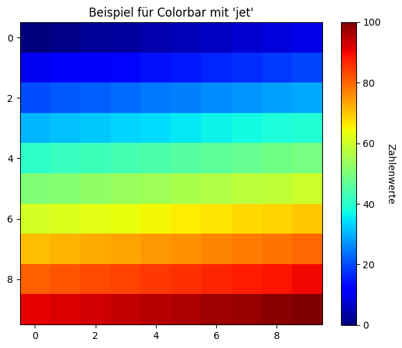

```python
import numpy as np
import matplotlib.pyplot as plt

# 1. Beispieldaten erstellen (z. B. Werte von 0 bis 100)
data = np.linspace(0, 100, 100).reshape((10, 10))

# 2. Daten mit der 'jet'-Farbpalette darstellen
plt.figure(figsize=(6, 5))
img = plt.imshow(data, cmap='jet')

# 3. Colorbar hinzufügen (Zahlenwerte werden automatisch angezeigt)
cbar = plt.colorbar(img)
cbar.set_label('Zahlenwerte', rotation=270, labelpad=15)

plt.title("Beispiel für Colorbar mit 'jet'")
plt.tight_layout()
plt.show()
```

## 4. Training: Verlust, Optimierer, Callbacks

↑ Inhaltsverzeichnis

### Was passiert hier?

`model.compile(...)` legt fest, **wie** gelernt werden soll — es rechnet noch nichts. Drei Angaben:

**1. Verlustfunktion `categorical_crossentropy`.** Sie misst den Abstand zwischen der vorhergesagten Verteilung $\hat{y}$ und dem One-Hot-Label $y$:

$$L \;=\; -\sum_{c=0}^{9} y_c \,\log \hat{y}_c$$

Weil $y$ One-Hot ist, bleibt davon nur **ein** Term übrig: $L = -\log \hat{y}_{\text{wahr}}$. Sagt das Netz für die richtige Klasse 0,99 voraus, ist $L \approx 0{,}01$; sagt es 0,01, ist $L \approx 4{,}6$. Der Logarithmus bestraft **selbstbewusste Fehler** also extrem hart — genau das will man.

**2. Optimierer `Adam(1e-3)`.** Gradientenabstieg mit adaptiver Schrittweite pro Parameter. Die Lernrate $10^{-3}$ ist der übliche Startwert.

**3. Metrik `accuracy`.** Nur zur Anzeige — der Anteil korrekt klassifizierter Beispiele. Die Metrik wird *nicht* optimiert (Genauigkeit ist nicht differenzierbar), sie ist aber die Zahl, die ein Mensch versteht.

### Der Callback: `ReduceLROnPlateau`

```
ReduceLROnPlateau(monitor="loss", factor=0.1, patience=5, verbose=1)
```

Übersetzt: *„Wenn sich der Trainingsverlust 5 Epochen lang nicht verbessert, multipliziere die Lernrate mit 0,1."* Aus $10^{-3}$ wird also $10^{-4}$, dann $10^{-5}$.

Die Idee ist anschaulich: Große Schritte bringen einen schnell ins Tal, aber am Talboden springt man darüber hinweg. Dann muss man kleiner treten. Ein solcher **Lernraten-Zeitplan** ist der billigste bekannte Weg zu ein paar Prozentpunkten mehr Genauigkeit.

⚠️ Hier wird `monitor="loss"` überwacht, also der **Trainings**verlust. Üblicher (und sicherer) wäre `val_loss`: Sinkt nur der Trainingsverlust weiter, während der Validierungsverlust steigt, lernt das Netz auswendig — das würde dieser Callback nicht bemerken.

### Wo bleibt `model.fit`?

Diese Zelle **bereitet das Training nur vor**. Der eigentliche Aufruf steht in Abschnitt 5, denn erst dort wird entschieden, ob überhaupt trainiert werden muss: Liegt schon ein gespeichertes Modell vor, wird es geladen und `model.fit` übersprungen.

Der Grund für diese Trennung: 100 Epochen dauern auf einer Laptop-GPU einige Minuten. Dieses Notebook ist in erster Linie ein **Analyse**-Notebook; man soll es von oben bis unten durchlaufen lassen können, ohne jedes Mal neu zu trainieren.

Die Einstellungen, mit denen Abschnitt 5 im Trainingsfall arbeitet:

| Parameter | Wert | Bedeutung |
| --- | --- | --- |
| `epochs=100` | 100 Durchläufe durch alle 10.000 Beispiele |  |
| `batch_size=32` | 32 Volumen pro Gradientenschritt → 313 Schritte je Epoche |  |
| `shuffle=True` | Reihenfolge jede Epoche neu mischen | verhindert Ordnungseffekte |
| `validation_data=(test_X, test_y)` | nach jeder Epoche auf den 2.000 Testdaten messen | ehrliche Zwischenbilanz |

### Einordnung

Die strikte Trennung „Training einmal, Analyse beliebig oft" ist bei 3D-Daten keine Bequemlichkeit, sondern Notwendigkeit: Beim MRT-Pendant dieses Notebooks dauert ein Trainingslauf Stunden bis Tage auf dedizierter Hardware. Das Modell ist dort ein **Artefakt**, das man versioniert, ablegt und wiederverwendet — genau wie hier in `output/notebooks/<Notebook-Name>/`.

```python
from tensorflow.keras.callbacks import ReduceLROnPlateau
from tensorflow.keras.optimizers import Adam

model.compile(loss='categorical_crossentropy', optimizer=Adam(1e-3),
              metrics=['accuracy'])

callbacks = [
    ReduceLROnPlateau(
        monitor="loss",
        factor=0.1,
        patience=5,
        verbose=1
    )
]
```

## 5. Das Modell: laden oder trainieren

↑ Inhaltsverzeichnis

### Was passiert hier?

Die Zelle sucht mit `MODEL_DIR.glob("*.keras")` nach einem bereits gespeicherten Modell und verzweigt danach:

- **Datei gefunden** → `load_model(...)` **überschreibt** die Variable `model`. Das in Abschnitt 2 gebaute Netz mit seinen Zufallsgewichten wird verworfen und durch das trainierte ersetzt. Es wird *nicht* trainiert.
- **Keine Datei** → es wird 100 Epochen lang trainiert und das Ergebnis mit `model.save(...)` abgelegt. Beim nächsten Durchlauf greift dann der obere Zweig.

Architektur, Gewichte, Optimierer-Zustand und Trainingskonfiguration stecken alle in der einen Datei `3d_mnist_cnn.keras`. `MODEL_DIR.mkdir(parents=True, exist_ok=True)` legt den Ordner an, falls er fehlt, und beschwert sich nicht, wenn er schon existiert.

Dieses **Caching-Muster** verwenden alle Trainings-Notebooks dieses Repos. Das Modell landet unter `output/notebooks/<Notebook-Name>/100_epochs/` — also im selben Ausgabeordner wie die Grafiken, jedes Notebook in seinem eigenen. Wer bewusst neu trainieren will, löscht oder verschiebt die `.keras`-Datei.

⚠️ Die Suche per `glob` nimmt die **erste** `.keras`-Datei in alphabetischer Reihenfolge — liegen dort mehrere Modelle, wird nicht unbedingt das geladen, das `MODEL_PATH` benennt.

### Ausgabe

[output not shown]

### Warum `.keras` und nicht `.h5`?

`.keras` ist seit Keras 3 das empfohlene Format. Es ist intern ein ZIP-Archiv aus JSON-Konfiguration und Gewichtsdatei und speichert im Gegensatz zum alten HDF5-Format auch benutzerdefinierte Objekte zuverlässig. Der Ordnername `100_epochs` dokumentiert nebenbei die wichtigste Trainings-Einstellung — ein simples, aber wirksames Ordnungsprinzip.

### ⚠️ Was hier fehlt

Es wird **keine Testgenauigkeit ausgegeben**. Ein `model.evaluate(test_X, test_y)` würde hier gut hinpassen, denn:

> **Eine Erklärung ist nur so viel wert wie das Modell, das sie erklärt.**

Eine hübsche Heatmap für ein Netz mit 40 % Genauigkeit erklärt vor allem, wie das Netz sich irrt. Das ist einer der häufigsten Anfängerfehler in der XAI: die Heatmap interpretieren, ohne vorher die Modellgüte zu prüfen. Immerhin liefert Abschnitt 10 später eine Stichprobe (Vorhersage vs. wahres Label für ein Beispiel) — eine echte Evaluation auf dem Testsatz ersetzt das nicht.

### Einordnung

Ab hier ist das Notebook ein reines **Analyse-Notebook**. Alles Folgende — Vorhersagen, Erklärungen, 3D-Plots — sind Vorwärtsdurchläufe durch ein eingefrorenes Modell. Kein Gewicht ändert sich mehr.

```python
from tensorflow.keras.models import load_model

MODEL_DIR = target_dir / "100_epochs"
MODEL_DIR.mkdir(parents=True, exist_ok=True)
MODEL_PATH = MODEL_DIR / "3d_mnist_cnn.keras"

existing_model_path = next(iter(sorted(MODEL_DIR.glob("*.keras"))), None)

if existing_model_path is not None:
    model = load_model(existing_model_path)
    print(f"Model geladen von: {existing_model_path}")
else:
    model.fit(train_X, train_y,
              validation_data=(test_X, test_y),
              #epochs=2,
              epochs=100,
              batch_size=32,
              shuffle=True,
              callbacks=callbacks)

    model.save(MODEL_PATH)
    print(f"Model gespeichert unter: {MODEL_PATH}")
```

[output not shown]

[output not shown]

```
  1/313 ━━━━━━━━━━━━━━━━━━━━ 1:41:05 19s/step - accuracy: 0.0938 - loss: 3.3885
```

```
  8/313 ━━━━━━━━━━━━━━━━━━━━ 2s 8ms/step - accuracy: 0.1352 - loss: 3.3373
```

```
 15/313 ━━━━━━━━━━━━━━━━━━━━ 2s 8ms/step - accuracy: 0.1389 - loss: 3.3425
```

```
 22/313 ━━━━━━━━━━━━━━━━━━━━ 2s 8ms/step - accuracy: 0.1387 - loss: 3.3369
```

[output not shown]

```
 29/313 ━━━━━━━━━━━━━━━━━━━━ 2s 8ms/step - accuracy: 0.1361 - loss: 3.3297
```

```
 37/313 ━━━━━━━━━━━━━━━━━━━━ 2s 7ms/step - accuracy: 0.1336 - loss: 3.3169
```

```
 45/313 ━━━━━━━━━━━━━━━━━━━━ 1s 7ms/step - accuracy: 0.1322 - loss: 3.3031
```

```
 53/313 ━━━━━━━━━━━━━━━━━━━━ 1s 7ms/step - accuracy: 0.1324 - loss: 3.2884
```

```
 61/313 ━━━━━━━━━━━━━━━━━━━━ 1s 7ms/step - accuracy: 0.1332 - loss: 3.2729
```

```
 68/313 ━━━━━━━━━━━━━━━━━━━━ 1s 7ms/step - accuracy: 0.1342 - loss: 3.2589
```

```
 76/313 ━━━━━━━━━━━━━━━━━━━━ 1s 7ms/step - accuracy: 0.1357 - loss: 3.2430
```

```
 84/313 ━━━━━━━━━━━━━━━━━━━━ 1s 7ms/step - accuracy: 0.1374 - loss: 3.2274
```

```
 92/313 ━━━━━━━━━━━━━━━━━━━━ 1s 7ms/step - accuracy: 0.1394 - loss: 3.2122
```

```
100/313 ━━━━━━━━━━━━━━━━━━━━ 1s 7ms/step - accuracy: 0.1415 - loss: 3.1974
```

```
107/313 ━━━━━━━━━━━━━━━━━━━━ 1s 7ms/step - accuracy: 0.1435 - loss: 3.1847
```

```
114/313 ━━━━━━━━━━━━━━━━━━━━ 1s 7ms/step - accuracy: 0.1457 - loss: 3.1723
```

```
121/313 ━━━━━━━━━━━━━━━━━━━━ 1s 7ms/step - accuracy: 0.1479 - loss: 3.1604
```

```
128/313 ━━━━━━━━━━━━━━━━━━━━ 1s 7ms/step - accuracy: 0.1502 - loss: 3.1490
```

```
136/313 ━━━━━━━━━━━━━━━━━━━━ 1s 7ms/step - accuracy: 0.1525 - loss: 3.1369
```

```
143/313 ━━━━━━━━━━━━━━━━━━━━ 1s 7ms/step - accuracy: 0.1544 - loss: 3.1267
```

```
150/313 ━━━━━━━━━━━━━━━━━━━━ 1s 7ms/step - accuracy: 0.1563 - loss: 3.1167
```

```
157/313 ━━━━━━━━━━━━━━━━━━━━ 1s 7ms/step - accuracy: 0.1581 - loss: 3.1070
```

```
165/313 ━━━━━━━━━━━━━━━━━━━━ 1s 7ms/step - accuracy: 0.1603 - loss: 3.0960
```

```
173/313 ━━━━━━━━━━━━━━━━━━━━ 1s 7ms/step - accuracy: 0.1625 - loss: 3.0851
```

```
181/313 ━━━━━━━━━━━━━━━━━━━━ 0s 7ms/step - accuracy: 0.1647 - loss: 3.0743
```

```
189/313 ━━━━━━━━━━━━━━━━━━━━ 0s 7ms/step - accuracy: 0.1668 - loss: 3.0637
```

```
197/313 ━━━━━━━━━━━━━━━━━━━━ 0s 7ms/step - accuracy: 0.1690 - loss: 3.0533
```

```
205/313 ━━━━━━━━━━━━━━━━━━━━ 0s 7ms/step - accuracy: 0.1711 - loss: 3.0431
```

```
213/313 ━━━━━━━━━━━━━━━━━━━━ 0s 7ms/step - accuracy: 0.1731 - loss: 3.0331
```

```
221/313 ━━━━━━━━━━━━━━━━━━━━ 0s 7ms/step - accuracy: 0.1752 - loss: 3.0232
```

```
229/313 ━━━━━━━━━━━━━━━━━━━━ 0s 7ms/step - accuracy: 0.1772 - loss: 3.0135
```

```
237/313 ━━━━━━━━━━━━━━━━━━━━ 0s 7ms/step - accuracy: 0.1792 - loss: 3.0038
```

```
245/313 ━━━━━━━━━━━━━━━━━━━━ 0s 7ms/step - accuracy: 0.1812 - loss: 2.9944
```

```
253/313 ━━━━━━━━━━━━━━━━━━━━ 0s 7ms/step - accuracy: 0.1831 - loss: 2.9850
```

```
260/313 ━━━━━━━━━━━━━━━━━━━━ 0s 7ms/step - accuracy: 0.1849 - loss: 2.9768
```

```
268/313 ━━━━━━━━━━━━━━━━━━━━ 0s 7ms/step - accuracy: 0.1869 - loss: 2.9677
```

```
276/313 ━━━━━━━━━━━━━━━━━━━━ 0s 7ms/step - accuracy: 0.1888 - loss: 2.9586
```

```
284/313 ━━━━━━━━━━━━━━━━━━━━ 0s 7ms/step - accuracy: 0.1908 - loss: 2.9497
```

```
292/313 ━━━━━━━━━━━━━━━━━━━━ 0s 7ms/step - accuracy: 0.1927 - loss: 2.9410
```

```
300/313 ━━━━━━━━━━━━━━━━━━━━ 0s 7ms/step - accuracy: 0.1945 - loss: 2.9324
```

```
308/313 ━━━━━━━━━━━━━━━━━━━━ 0s 7ms/step - accuracy: 0.1964 - loss: 2.9239
```

[output not shown]

```
313/313 ━━━━━━━━━━━━━━━━━━━━ 0s 46ms/step - accuracy: 0.1976 - loss: 2.9187
```

```
313/313 ━━━━━━━━━━━━━━━━━━━━ 37s 58ms/step - accuracy: 0.2695 - loss: 2.5959 - val_accuracy: 0.1715 - val_loss: 2.7296 - learning_rate: 0.0010
```

```
  1/313 ━━━━━━━━━━━━━━━━━━━━ 9s 29ms/step - accuracy: 0.3438 - loss: 2.1562
```

```
  8/313 ━━━━━━━━━━━━━━━━━━━━ 2s 8ms/step - accuracy: 0.3598 - loss: 2.1132
```

```
 15/313 ━━━━━━━━━━━━━━━━━━━━ 2s 7ms/step - accuracy: 0.3693 - loss: 2.1066
```

```
 22/313 ━━━━━━━━━━━━━━━━━━━━ 2s 7ms/step - accuracy: 0.3754 - loss: 2.0981
```

```
 29/313 ━━━━━━━━━━━━━━━━━━━━ 2s 7ms/step - accuracy: 0.3812 - loss: 2.0878
```

```
 36/313 ━━━━━━━━━━━━━━━━━━━━ 2s 7ms/step - accuracy: 0.3854 - loss: 2.0816
```

```
 43/313 ━━━━━━━━━━━━━━━━━━━━ 2s 7ms/step - accuracy: 0.3873 - loss: 2.0807
```

```
 51/313 ━━━━━━━━━━━━━━━━━━━━ 1s 7ms/step - accuracy: 0.3895 - loss: 2.0787
```

```
 59/313 ━━━━━━━━━━━━━━━━━━━━ 1s 7ms/step - accuracy: 0.3909 - loss: 2.0765
```

```
 66/313 ━━━━━━━━━━━━━━━━━━━━ 1s 7ms/step - accuracy: 0.3920 - loss: 2.0752
```

```
 73/313 ━━━━━━━━━━━━━━━━━━━━ 1s 7ms/step - accuracy: 0.3934 - loss: 2.0731
```

```
 80/313 ━━━━━━━━━━━━━━━━━━━━ 1s 7ms/step - accuracy: 0.3945 - loss: 2.0709
```

```
 87/313 ━━━━━━━━━━━━━━━━━━━━ 1s 7ms/step - accuracy: 0.3954 - loss: 2.0688
```

```
 95/313 ━━━━━━━━━━━━━━━━━━━━ 1s 7ms/step - accuracy: 0.3960 - loss: 2.0665
```

```
103/313 ━━━━━━━━━━━━━━━━━━━━ 1s 7ms/step - accuracy: 0.3966 - loss: 2.0642
```

```
111/313 ━━━━━━━━━━━━━━━━━━━━ 1s 7ms/step - accuracy: 0.3973 - loss: 2.0618
```

```
118/313 ━━━━━━━━━━━━━━━━━━━━ 1s 7ms/step - accuracy: 0.3978 - loss: 2.0597
```

```
126/313 ━━━━━━━━━━━━━━━━━━━━ 1s 7ms/step - accuracy: 0.3985 - loss: 2.0573
```

```
134/313 ━━━━━━━━━━━━━━━━━━━━ 1s 7ms/step - accuracy: 0.3991 - loss: 2.0547
```

```
142/313 ━━━━━━━━━━━━━━━━━━━━ 1s 7ms/step - accuracy: 0.3998 - loss: 2.0520
```

```
150/313 ━━━━━━━━━━━━━━━━━━━━ 1s 7ms/step - accuracy: 0.4005 - loss: 2.0496
```

```
157/313 ━━━━━━━━━━━━━━━━━━━━ 1s 7ms/step - accuracy: 0.4010 - loss: 2.0476
```

```
165/313 ━━━━━━━━━━━━━━━━━━━━ 1s 7ms/step - accuracy: 0.4015 - loss: 2.0454
```

```
172/313 ━━━━━━━━━━━━━━━━━━━━ 1s 7ms/step - accuracy: 0.4020 - loss: 2.0436
```

```
179/313 ━━━━━━━━━━━━━━━━━━━━ 0s 7ms/step - accuracy: 0.4025 - loss: 2.0418
```

```
187/313 ━━━━━━━━━━━━━━━━━━━━ 0s 7ms/step - accuracy: 0.4031 - loss: 2.0398
```

```
195/313 ━━━━━━━━━━━━━━━━━━━━ 0s 7ms/step - accuracy: 0.4038 - loss: 2.0377
```

```
203/313 ━━━━━━━━━━━━━━━━━━━━ 0s 7ms/step - accuracy: 0.4045 - loss: 2.0357
```

```
210/313 ━━━━━━━━━━━━━━━━━━━━ 0s 7ms/step - accuracy: 0.4051 - loss: 2.0340
```

```
217/313 ━━━━━━━━━━━━━━━━━━━━ 0s 7ms/step - accuracy: 0.4057 - loss: 2.0322
```

```
225/313 ━━━━━━━━━━━━━━━━━━━━ 0s 7ms/step - accuracy: 0.4063 - loss: 2.0302
```

```
233/313 ━━━━━━━━━━━━━━━━━━━━ 0s 7ms/step - accuracy: 0.4069 - loss: 2.0283
```

```
241/313 ━━━━━━━━━━━━━━━━━━━━ 0s 7ms/step - accuracy: 0.4076 - loss: 2.0264
```

```
248/313 ━━━━━━━━━━━━━━━━━━━━ 0s 7ms/step - accuracy: 0.4081 - loss: 2.0248
```

```
255/313 ━━━━━━━━━━━━━━━━━━━━ 0s 7ms/step - accuracy: 0.4086 - loss: 2.0233
```

```
262/313 ━━━━━━━━━━━━━━━━━━━━ 0s 7ms/step - accuracy: 0.4092 - loss: 2.0217
```

```
270/313 ━━━━━━━━━━━━━━━━━━━━ 0s 7ms/step - accuracy: 0.4098 - loss: 2.0200
```

```
278/313 ━━━━━━━━━━━━━━━━━━━━ 0s 7ms/step - accuracy: 0.4104 - loss: 2.0182
```

```
286/313 ━━━━━━━━━━━━━━━━━━━━ 0s 7ms/step - accuracy: 0.4110 - loss: 2.0164
```

```
294/313 ━━━━━━━━━━━━━━━━━━━━ 0s 7ms/step - accuracy: 0.4117 - loss: 2.0146
```

```
302/313 ━━━━━━━━━━━━━━━━━━━━ 0s 7ms/step - accuracy: 0.4123 - loss: 2.0129
```

```
310/313 ━━━━━━━━━━━━━━━━━━━━ 0s 7ms/step - accuracy: 0.4128 - loss: 2.0113
```

```
313/313 ━━━━━━━━━━━━━━━━━━━━ 2s 8ms/step - accuracy: 0.4353 - loss: 1.9467 - val_accuracy: 0.4365 - val_loss: 1.9582 - learning_rate: 0.0010
```

```
  1/313 ━━━━━━━━━━━━━━━━━━━━ 8s 26ms/step - accuracy: 0.4375 - loss: 1.8240
```

```
  8/313 ━━━━━━━━━━━━━━━━━━━━ 2s 7ms/step - accuracy: 0.4381 - loss: 1.8476
```

```
 16/313 ━━━━━━━━━━━━━━━━━━━━ 2s 7ms/step - accuracy: 0.4427 - loss: 1.8562
```

```
 24/313 ━━━━━━━━━━━━━━━━━━━━ 2s 7ms/step - accuracy: 0.4415 - loss: 1.8619
```

```
 32/313 ━━━━━━━━━━━━━━━━━━━━ 1s 7ms/step - accuracy: 0.4397 - loss: 1.8666
```

```
 40/313 ━━━━━━━━━━━━━━━━━━━━ 1s 7ms/step - accuracy: 0.4403 - loss: 1.8665
```

```
 47/313 ━━━━━━━━━━━━━━━━━━━━ 1s 7ms/step - accuracy: 0.4420 - loss: 1.8640
```

```
 55/313 ━━━━━━━━━━━━━━━━━━━━ 1s 7ms/step - accuracy: 0.4438 - loss: 1.8600
```

```
 62/313 ━━━━━━━━━━━━━━━━━━━━ 1s 7ms/step - accuracy: 0.4454 - loss: 1.8568
```

```
 69/313 ━━━━━━━━━━━━━━━━━━━━ 1s 7ms/step - accuracy: 0.4468 - loss: 1.8538
```

```
 77/313 ━━━━━━━━━━━━━━━━━━━━ 1s 7ms/step - accuracy: 0.4477 - loss: 1.8513
```

```
 84/313 ━━━━━━━━━━━━━━━━━━━━ 1s 7ms/step - accuracy: 0.4482 - loss: 1.8493
```

```
 91/313 ━━━━━━━━━━━━━━━━━━━━ 1s 7ms/step - accuracy: 0.4485 - loss: 1.8476
```

```
 99/313 ━━━━━━━━━━━━━━━━━━━━ 1s 7ms/step - accuracy: 0.4489 - loss: 1.8459
```

```
107/313 ━━━━━━━━━━━━━━━━━━━━ 1s 7ms/step - accuracy: 0.4497 - loss: 1.8434
```

```
115/313 ━━━━━━━━━━━━━━━━━━━━ 1s 7ms/step - accuracy: 0.4505 - loss: 1.8410
```

```
123/313 ━━━━━━━━━━━━━━━━━━━━ 1s 7ms/step - accuracy: 0.4514 - loss: 1.8388
```

```
131/313 ━━━━━━━━━━━━━━━━━━━━ 1s 7ms/step - accuracy: 0.4523 - loss: 1.8370
```

```
139/313 ━━━━━━━━━━━━━━━━━━━━ 1s 7ms/step - accuracy: 0.4530 - loss: 1.8354
```

```
147/313 ━━━━━━━━━━━━━━━━━━━━ 1s 7ms/step - accuracy: 0.4537 - loss: 1.8339
```

```
155/313 ━━━━━━━━━━━━━━━━━━━━ 1s 7ms/step - accuracy: 0.4544 - loss: 1.8324
```

```
163/313 ━━━━━━━━━━━━━━━━━━━━ 1s 7ms/step - accuracy: 0.4549 - loss: 1.8314
```

```
170/313 ━━━━━━━━━━━━━━━━━━━━ 1s 7ms/step - accuracy: 0.4554 - loss: 1.8306
```

```
177/313 ━━━━━━━━━━━━━━━━━━━━ 0s 7ms/step - accuracy: 0.4557 - loss: 1.8300
```

```
185/313 ━━━━━━━━━━━━━━━━━━━━ 0s 7ms/step - accuracy: 0.4562 - loss: 1.8294
```

```
193/313 ━━━━━━━━━━━━━━━━━━━━ 0s 7ms/step - accuracy: 0.4566 - loss: 1.8287
```

```
201/313 ━━━━━━━━━━━━━━━━━━━━ 0s 7ms/step - accuracy: 0.4570 - loss: 1.8283
```

```
209/313 ━━━━━━━━━━━━━━━━━━━━ 0s 7ms/step - accuracy: 0.4574 - loss: 1.8278
```

```
217/313 ━━━━━━━━━━━━━━━━━━━━ 0s 7ms/step - accuracy: 0.4578 - loss: 1.8272
```

```
225/313 ━━━━━━━━━━━━━━━━━━━━ 0s 7ms/step - accuracy: 0.4583 - loss: 1.8265
```

```
233/313 ━━━━━━━━━━━━━━━━━━━━ 0s 7ms/step - accuracy: 0.4588 - loss: 1.8257
```

```
241/313 ━━━━━━━━━━━━━━━━━━━━ 0s 7ms/step - accuracy: 0.4593 - loss: 1.8250
```

```
249/313 ━━━━━━━━━━━━━━━━━━━━ 0s 7ms/step - accuracy: 0.4597 - loss: 1.8244
```

```
257/313 ━━━━━━━━━━━━━━━━━━━━ 0s 7ms/step - accuracy: 0.4601 - loss: 1.8236
```

```
264/313 ━━━━━━━━━━━━━━━━━━━━ 0s 7ms/step - accuracy: 0.4605 - loss: 1.8230
```

```
272/313 ━━━━━━━━━━━━━━━━━━━━ 0s 7ms/step - accuracy: 0.4608 - loss: 1.8222
```

```
279/313 ━━━━━━━━━━━━━━━━━━━━ 0s 7ms/step - accuracy: 0.4612 - loss: 1.8215
```

```
287/313 ━━━━━━━━━━━━━━━━━━━━ 0s 7ms/step - accuracy: 0.4615 - loss: 1.8207
```

```
294/313 ━━━━━━━━━━━━━━━━━━━━ 0s 7ms/step - accuracy: 0.4619 - loss: 1.8200
```

```
301/313 ━━━━━━━━━━━━━━━━━━━━ 0s 7ms/step - accuracy: 0.4622 - loss: 1.8193
```

```
308/313 ━━━━━━━━━━━━━━━━━━━━ 0s 7ms/step - accuracy: 0.4626 - loss: 1.8185
```

```
313/313 ━━━━━━━━━━━━━━━━━━━━ 2s 8ms/step - accuracy: 0.4770 - loss: 1.7864 - val_accuracy: 0.5765 - val_loss: 1.5515 - learning_rate: 0.0010
```

```
  1/313 ━━━━━━━━━━━━━━━━━━━━ 8s 27ms/step - accuracy: 0.5312 - loss: 1.8557
```

```
  8/313 ━━━━━━━━━━━━━━━━━━━━ 2s 7ms/step - accuracy: 0.4878 - loss: 1.8583
```

```
 15/313 ━━━━━━━━━━━━━━━━━━━━ 2s 7ms/step - accuracy: 0.4884 - loss: 1.8363
```

```
 23/313 ━━━━━━━━━━━━━━━━━━━━ 2s 7ms/step - accuracy: 0.4892 - loss: 1.8180
```

```
 30/313 ━━━━━━━━━━━━━━━━━━━━ 2s 7ms/step - accuracy: 0.4917 - loss: 1.8006
```

```
 38/313 ━━━━━━━━━━━━━━━━━━━━ 1s 7ms/step - accuracy: 0.4943 - loss: 1.7859
```

```
 46/313 ━━━━━━━━━━━━━━━━━━━━ 1s 7ms/step - accuracy: 0.4962 - loss: 1.7774
```

```
 53/313 ━━━━━━━━━━━━━━━━━━━━ 1s 7ms/step - accuracy: 0.4978 - loss: 1.7713
```

```
 61/313 ━━━━━━━━━━━━━━━━━━━━ 1s 7ms/step - accuracy: 0.4993 - loss: 1.7658
```

```
 68/313 ━━━━━━━━━━━━━━━━━━━━ 1s 7ms/step - accuracy: 0.5007 - loss: 1.7613
```

```
 75/313 ━━━━━━━━━━━━━━━━━━━━ 1s 7ms/step - accuracy: 0.5021 - loss: 1.7570
```

```
 83/313 ━━━━━━━━━━━━━━━━━━━━ 1s 7ms/step - accuracy: 0.5036 - loss: 1.7519
```

```
 90/313 ━━━━━━━━━━━━━━━━━━━━ 1s 7ms/step - accuracy: 0.5046 - loss: 1.7481
```

```
 98/313 ━━━━━━━━━━━━━━━━━━━━ 1s 7ms/step - accuracy: 0.5058 - loss: 1.7439
```

```
106/313 ━━━━━━━━━━━━━━━━━━━━ 1s 7ms/step - accuracy: 0.5065 - loss: 1.7407
```

```
114/313 ━━━━━━━━━━━━━━━━━━━━ 1s 7ms/step - accuracy: 0.5072 - loss: 1.7378
```

```
122/313 ━━━━━━━━━━━━━━━━━━━━ 1s 7ms/step - accuracy: 0.5077 - loss: 1.7353
```

```
130/313 ━━━━━━━━━━━━━━━━━━━━ 1s 7ms/step - accuracy: 0.5081 - loss: 1.7330
```

```
138/313 ━━━━━━━━━━━━━━━━━━━━ 1s 7ms/step - accuracy: 0.5085 - loss: 1.7310
```

```
146/313 ━━━━━━━━━━━━━━━━━━━━ 1s 7ms/step - accuracy: 0.5087 - loss: 1.7295
```

```
154/313 ━━━━━━━━━━━━━━━━━━━━ 1s 7ms/step - accuracy: 0.5089 - loss: 1.7281
```

```
162/313 ━━━━━━━━━━━━━━━━━━━━ 1s 7ms/step - accuracy: 0.5089 - loss: 1.7270
```

```
170/313 ━━━━━━━━━━━━━━━━━━━━ 1s 7ms/step - accuracy: 0.5089 - loss: 1.7262
```

```
178/313 ━━━━━━━━━━━━━━━━━━━━ 0s 7ms/step - accuracy: 0.5089 - loss: 1.7254
```

```
186/313 ━━━━━━━━━━━━━━━━━━━━ 0s 7ms/step - accuracy: 0.5089 - loss: 1.7246
```

```
193/313 ━━━━━━━━━━━━━━━━━━━━ 0s 7ms/step - accuracy: 0.5088 - loss: 1.7243
```

```
201/313 ━━━━━━━━━━━━━━━━━━━━ 0s 7ms/step - accuracy: 0.5087 - loss: 1.7240
```

```
208/313 ━━━━━━━━━━━━━━━━━━━━ 0s 7ms/step - accuracy: 0.5085 - loss: 1.7238
```

```
215/313 ━━━━━━━━━━━━━━━━━━━━ 0s 7ms/step - accuracy: 0.5084 - loss: 1.7235
```

```
222/313 ━━━━━━━━━━━━━━━━━━━━ 0s 7ms/step - accuracy: 0.5083 - loss: 1.7233
```

```
229/313 ━━━━━━━━━━━━━━━━━━━━ 0s 7ms/step - accuracy: 0.5082 - loss: 1.7229
```

```
236/313 ━━━━━━━━━━━━━━━━━━━━ 0s 7ms/step - accuracy: 0.5082 - loss: 1.7225
```

```
244/313 ━━━━━━━━━━━━━━━━━━━━ 0s 7ms/step - accuracy: 0.5082 - loss: 1.7221
```

```
252/313 ━━━━━━━━━━━━━━━━━━━━ 0s 7ms/step - accuracy: 0.5081 - loss: 1.7216
```

```
260/313 ━━━━━━━━━━━━━━━━━━━━ 0s 7ms/step - accuracy: 0.5082 - loss: 1.7211
```

```
268/313 ━━━━━━━━━━━━━━━━━━━━ 0s 7ms/step - accuracy: 0.5082 - loss: 1.7205
```

```
276/313 ━━━━━━━━━━━━━━━━━━━━ 0s 7ms/step - accuracy: 0.5082 - loss: 1.7200
```

```
284/313 ━━━━━━━━━━━━━━━━━━━━ 0s 7ms/step - accuracy: 0.5083 - loss: 1.7195
```

```
292/313 ━━━━━━━━━━━━━━━━━━━━ 0s 7ms/step - accuracy: 0.5084 - loss: 1.7190
```

```
300/313 ━━━━━━━━━━━━━━━━━━━━ 0s 7ms/step - accuracy: 0.5084 - loss: 1.7185
```

```
308/313 ━━━━━━━━━━━━━━━━━━━━ 0s 7ms/step - accuracy: 0.5085 - loss: 1.7179
```

```
313/313 ━━━━━━━━━━━━━━━━━━━━ 2s 8ms/step - accuracy: 0.5113 - loss: 1.6935 - val_accuracy: 0.5960 - val_loss: 1.4849 - learning_rate: 0.0010
```

```
  1/313 ━━━━━━━━━━━━━━━━━━━━ 8s 26ms/step - accuracy: 0.5625 - loss: 1.6935
```

```
  9/313 ━━━━━━━━━━━━━━━━━━━━ 2s 7ms/step - accuracy: 0.5853 - loss: 1.5733
```

```
 17/313 ━━━━━━━━━━━━━━━━━━━━ 2s 7ms/step - accuracy: 0.5788 - loss: 1.5632
```

```
 25/313 ━━━━━━━━━━━━━━━━━━━━ 2s 7ms/step - accuracy: 0.5738 - loss: 1.5662
```

```
 33/313 ━━━━━━━━━━━━━━━━━━━━ 1s 7ms/step - accuracy: 0.5687 - loss: 1.5742
```

```
 41/313 ━━━━━━━━━━━━━━━━━━━━ 1s 7ms/step - accuracy: 0.5645 - loss: 1.5818
```

```
 49/313 ━━━━━━━━━━━━━━━━━━━━ 1s 7ms/step - accuracy: 0.5608 - loss: 1.5872
```

```
 57/313 ━━━━━━━━━━━━━━━━━━━━ 1s 7ms/step - accuracy: 0.5581 - loss: 1.5906
```

```
 65/313 ━━━━━━━━━━━━━━━━━━━━ 1s 7ms/step - accuracy: 0.5561 - loss: 1.5925
```

```
 73/313 ━━━━━━━━━━━━━━━━━━━━ 1s 7ms/step - accuracy: 0.5542 - loss: 1.5945
```

```
 81/313 ━━━━━━━━━━━━━━━━━━━━ 1s 7ms/step - accuracy: 0.5523 - loss: 1.5962
```

```
 89/313 ━━━━━━━━━━━━━━━━━━━━ 1s 7ms/step - accuracy: 0.5507 - loss: 1.5982
```

```
 97/313 ━━━━━━━━━━━━━━━━━━━━ 1s 7ms/step - accuracy: 0.5494 - loss: 1.6000
```

```
105/313 ━━━━━━━━━━━━━━━━━━━━ 1s 7ms/step - accuracy: 0.5485 - loss: 1.6013
```

```
113/313 ━━━━━━━━━━━━━━━━━━━━ 1s 7ms/step - accuracy: 0.5479 - loss: 1.6019
```

```
121/313 ━━━━━━━━━━━━━━━━━━━━ 1s 7ms/step - accuracy: 0.5475 - loss: 1.6019
```

```
129/313 ━━━━━━━━━━━━━━━━━━━━ 1s 7ms/step - accuracy: 0.5474 - loss: 1.6015
```

```
137/313 ━━━━━━━━━━━━━━━━━━━━ 1s 7ms/step - accuracy: 0.5473 - loss: 1.6014
```

```
145/313 ━━━━━━━━━━━━━━━━━━━━ 1s 7ms/step - accuracy: 0.5471 - loss: 1.6014
```

```
153/313 ━━━━━━━━━━━━━━━━━━━━ 1s 7ms/step - accuracy: 0.5469 - loss: 1.6012
```

```
161/313 ━━━━━━━━━━━━━━━━━━━━ 1s 7ms/step - accuracy: 0.5469 - loss: 1.6009
```

```
169/313 ━━━━━━━━━━━━━━━━━━━━ 0s 7ms/step - accuracy: 0.5468 - loss: 1.6007
```

```
177/313 ━━━━━━━━━━━━━━━━━━━━ 0s 7ms/step - accuracy: 0.5466 - loss: 1.6009
```

```
185/313 ━━━━━━━━━━━━━━━━━━━━ 0s 7ms/step - accuracy: 0.5465 - loss: 1.6011
```

```
193/313 ━━━━━━━━━━━━━━━━━━━━ 0s 7ms/step - accuracy: 0.5464 - loss: 1.6011
```

```
201/313 ━━━━━━━━━━━━━━━━━━━━ 0s 7ms/step - accuracy: 0.5463 - loss: 1.6012
```

```
209/313 ━━━━━━━━━━━━━━━━━━━━ 0s 7ms/step - accuracy: 0.5461 - loss: 1.6014
```

```
217/313 ━━━━━━━━━━━━━━━━━━━━ 0s 7ms/step - accuracy: 0.5460 - loss: 1.6018
```

```
225/313 ━━━━━━━━━━━━━━━━━━━━ 0s 7ms/step - accuracy: 0.5459 - loss: 1.6022
```

```
233/313 ━━━━━━━━━━━━━━━━━━━━ 0s 7ms/step - accuracy: 0.5458 - loss: 1.6025
```

```
241/313 ━━━━━━━━━━━━━━━━━━━━ 0s 7ms/step - accuracy: 0.5457 - loss: 1.6029
```

```
249/313 ━━━━━━━━━━━━━━━━━━━━ 0s 7ms/step - accuracy: 0.5456 - loss: 1.6034
```

```
257/313 ━━━━━━━━━━━━━━━━━━━━ 0s 7ms/step - accuracy: 0.5455 - loss: 1.6039
```

```
265/313 ━━━━━━━━━━━━━━━━━━━━ 0s 7ms/step - accuracy: 0.5453 - loss: 1.6044
```

```
273/313 ━━━━━━━━━━━━━━━━━━━━ 0s 7ms/step - accuracy: 0.5452 - loss: 1.6049
```

```
280/313 ━━━━━━━━━━━━━━━━━━━━ 0s 7ms/step - accuracy: 0.5451 - loss: 1.6054
```

```
288/313 ━━━━━━━━━━━━━━━━━━━━ 0s 7ms/step - accuracy: 0.5450 - loss: 1.6058
```

```
295/313 ━━━━━━━━━━━━━━━━━━━━ 0s 7ms/step - accuracy: 0.5449 - loss: 1.6062
```

```
303/313 ━━━━━━━━━━━━━━━━━━━━ 0s 7ms/step - accuracy: 0.5448 - loss: 1.6065
```

```
311/313 ━━━━━━━━━━━━━━━━━━━━ 0s 7ms/step - accuracy: 0.5448 - loss: 1.6069
```

```
313/313 ━━━━━━━━━━━━━━━━━━━━ 2s 8ms/step - accuracy: 0.5423 - loss: 1.6203 - val_accuracy: 0.5900 - val_loss: 1.4984 - learning_rate: 0.0010
```

```
  1/313 ━━━━━━━━━━━━━━━━━━━━ 8s 26ms/step - accuracy: 0.5000 - loss: 1.7460
```

```
  9/313 ━━━━━━━━━━━━━━━━━━━━ 2s 7ms/step - accuracy: 0.5150 - loss: 1.6192
```

```
 17/313 ━━━━━━━━━━━━━━━━━━━━ 2s 7ms/step - accuracy: 0.5210 - loss: 1.6059
```

```
 25/313 ━━━━━━━━━━━━━━━━━━━━ 1s 7ms/step - accuracy: 0.5273 - loss: 1.5992
```

```
 33/313 ━━━━━━━━━━━━━━━━━━━━ 1s 7ms/step - accuracy: 0.5332 - loss: 1.5928
```

```
 41/313 ━━━━━━━━━━━━━━━━━━━━ 1s 7ms/step - accuracy: 0.5365 - loss: 1.5960
```

```
 49/313 ━━━━━━━━━━━━━━━━━━━━ 1s 7ms/step - accuracy: 0.5376 - loss: 1.6004
```

```
 57/313 ━━━━━━━━━━━━━━━━━━━━ 1s 7ms/step - accuracy: 0.5384 - loss: 1.6041
```

```
 65/313 ━━━━━━━━━━━━━━━━━━━━ 1s 7ms/step - accuracy: 0.5392 - loss: 1.6070
```

```
 73/313 ━━━━━━━━━━━━━━━━━━━━ 1s 7ms/step - accuracy: 0.5397 - loss: 1.6098
```

```
 81/313 ━━━━━━━━━━━━━━━━━━━━ 1s 7ms/step - accuracy: 0.5410 - loss: 1.6109
```

```
 89/313 ━━━━━━━━━━━━━━━━━━━━ 1s 7ms/step - accuracy: 0.5424 - loss: 1.6113
```

```
 97/313 ━━━━━━━━━━━━━━━━━━━━ 1s 7ms/step - accuracy: 0.5439 - loss: 1.6112
```

```
105/313 ━━━━━━━━━━━━━━━━━━━━ 1s 7ms/step - accuracy: 0.5454 - loss: 1.6108
```

```
113/313 ━━━━━━━━━━━━━━━━━━━━ 1s 7ms/step - accuracy: 0.5466 - loss: 1.6106
```

```
121/313 ━━━━━━━━━━━━━━━━━━━━ 1s 7ms/step - accuracy: 0.5476 - loss: 1.6104
```

```
129/313 ━━━━━━━━━━━━━━━━━━━━ 1s 7ms/step - accuracy: 0.5486 - loss: 1.6099
```

```
137/313 ━━━━━━━━━━━━━━━━━━━━ 1s 7ms/step - accuracy: 0.5494 - loss: 1.6097
```

```
145/313 ━━━━━━━━━━━━━━━━━━━━ 1s 7ms/step - accuracy: 0.5500 - loss: 1.6098
```

```
153/313 ━━━━━━━━━━━━━━━━━━━━ 1s 7ms/step - accuracy: 0.5506 - loss: 1.6097
```

```
161/313 ━━━━━━━━━━━━━━━━━━━━ 1s 7ms/step - accuracy: 0.5512 - loss: 1.6096
```

```
169/313 ━━━━━━━━━━━━━━━━━━━━ 0s 7ms/step - accuracy: 0.5517 - loss: 1.6095
```

```
177/313 ━━━━━━━━━━━━━━━━━━━━ 0s 7ms/step - accuracy: 0.5522 - loss: 1.6095
```

```
185/313 ━━━━━━━━━━━━━━━━━━━━ 0s 7ms/step - accuracy: 0.5525 - loss: 1.6095
```

```
193/313 ━━━━━━━━━━━━━━━━━━━━ 0s 7ms/step - accuracy: 0.5530 - loss: 1.6094
```

```
201/313 ━━━━━━━━━━━━━━━━━━━━ 0s 7ms/step - accuracy: 0.5533 - loss: 1.6095
```

```
209/313 ━━━━━━━━━━━━━━━━━━━━ 0s 7ms/step - accuracy: 0.5535 - loss: 1.6097
```

```
217/313 ━━━━━━━━━━━━━━━━━━━━ 0s 7ms/step - accuracy: 0.5538 - loss: 1.6099
```

```
225/313 ━━━━━━━━━━━━━━━━━━━━ 0s 7ms/step - accuracy: 0.5540 - loss: 1.6101
```

```
233/313 ━━━━━━━━━━━━━━━━━━━━ 0s 7ms/step - accuracy: 0.5542 - loss: 1.6102
```

```
241/313 ━━━━━━━━━━━━━━━━━━━━ 0s 7ms/step - accuracy: 0.5544 - loss: 1.6103
```

```
249/313 ━━━━━━━━━━━━━━━━━━━━ 0s 7ms/step - accuracy: 0.5546 - loss: 1.6104
```

```
257/313 ━━━━━━━━━━━━━━━━━━━━ 0s 7ms/step - accuracy: 0.5548 - loss: 1.6106
```

```
265/313 ━━━━━━━━━━━━━━━━━━━━ 0s 7ms/step - accuracy: 0.5549 - loss: 1.6108
```

```
273/313 ━━━━━━━━━━━━━━━━━━━━ 0s 7ms/step - accuracy: 0.5550 - loss: 1.6109
```

```
281/313 ━━━━━━━━━━━━━━━━━━━━ 0s 7ms/step - accuracy: 0.5551 - loss: 1.6111
```

```
288/313 ━━━━━━━━━━━━━━━━━━━━ 0s 7ms/step - accuracy: 0.5553 - loss: 1.6112
```

```
296/313 ━━━━━━━━━━━━━━━━━━━━ 0s 7ms/step - accuracy: 0.5554 - loss: 1.6113
```

```
303/313 ━━━━━━━━━━━━━━━━━━━━ 0s 7ms/step - accuracy: 0.5555 - loss: 1.6114
```

```
311/313 ━━━━━━━━━━━━━━━━━━━━ 0s 7ms/step - accuracy: 0.5556 - loss: 1.6115
```

```
313/313 ━━━━━━━━━━━━━━━━━━━━ 2s 8ms/step - accuracy: 0.5610 - loss: 1.6135 - val_accuracy: 0.4965 - val_loss: 1.7549 - learning_rate: 0.0010
```

```
  1/313 ━━━━━━━━━━━━━━━━━━━━ 8s 27ms/step - accuracy: 0.5000 - loss: 1.7561
```

```
  8/313 ━━━━━━━━━━━━━━━━━━━━ 2s 7ms/step - accuracy: 0.5490 - loss: 1.6271
```

```
 16/313 ━━━━━━━━━━━━━━━━━━━━ 2s 7ms/step - accuracy: 0.5668 - loss: 1.5781
```

```
 24/313 ━━━━━━━━━━━━━━━━━━━━ 2s 7ms/step - accuracy: 0.5791 - loss: 1.5539
```

```
 32/313 ━━━━━━━━━━━━━━━━━━━━ 1s 7ms/step - accuracy: 0.5849 - loss: 1.5425
```

```
 40/313 ━━━━━━━━━━━━━━━━━━━━ 1s 7ms/step - accuracy: 0.5857 - loss: 1.5399
```

```
 48/313 ━━━━━━━━━━━━━━━━━━━━ 1s 7ms/step - accuracy: 0.5862 - loss: 1.5379
```

```
 56/313 ━━━━━━━━━━━━━━━━━━━━ 1s 7ms/step - accuracy: 0.5868 - loss: 1.5357
```

```
 64/313 ━━━━━━━━━━━━━━━━━━━━ 1s 7ms/step - accuracy: 0.5871 - loss: 1.5347
```

```
 72/313 ━━━━━━━━━━━━━━━━━━━━ 1s 7ms/step - accuracy: 0.5869 - loss: 1.5349
```

```
 80/313 ━━━━━━━━━━━━━━━━━━━━ 1s 7ms/step - accuracy: 0.5869 - loss: 1.5354
```

```
 88/313 ━━━━━━━━━━━━━━━━━━━━ 1s 7ms/step - accuracy: 0.5866 - loss: 1.5363
```

```
 96/313 ━━━━━━━━━━━━━━━━━━━━ 1s 7ms/step - accuracy: 0.5864 - loss: 1.5373
```

```
104/313 ━━━━━━━━━━━━━━━━━━━━ 1s 7ms/step - accuracy: 0.5862 - loss: 1.5379
```

```
112/313 ━━━━━━━━━━━━━━━━━━━━ 1s 7ms/step - accuracy: 0.5859 - loss: 1.5389
```

```
120/313 ━━━━━━━━━━━━━━━━━━━━ 1s 7ms/step - accuracy: 0.5854 - loss: 1.5400
```

```
128/313 ━━━━━━━━━━━━━━━━━━━━ 1s 7ms/step - accuracy: 0.5851 - loss: 1.5409
```

```
136/313 ━━━━━━━━━━━━━━━━━━━━ 1s 7ms/step - accuracy: 0.5848 - loss: 1.5413
```

```
144/313 ━━━━━━━━━━━━━━━━━━━━ 1s 7ms/step - accuracy: 0.5846 - loss: 1.5419
```

```
152/313 ━━━━━━━━━━━━━━━━━━━━ 1s 7ms/step - accuracy: 0.5843 - loss: 1.5427
```

```
159/313 ━━━━━━━━━━━━━━━━━━━━ 1s 7ms/step - accuracy: 0.5838 - loss: 1.5439
```

```
167/313 ━━━━━━━━━━━━━━━━━━━━ 1s 7ms/step - accuracy: 0.5833 - loss: 1.5452
```

```
175/313 ━━━━━━━━━━━━━━━━━━━━ 0s 7ms/step - accuracy: 0.5827 - loss: 1.5467
```

```
182/313 ━━━━━━━━━━━━━━━━━━━━ 0s 7ms/step - accuracy: 0.5823 - loss: 1.5479
```

```
190/313 ━━━━━━━━━━━━━━━━━━━━ 0s 7ms/step - accuracy: 0.5820 - loss: 1.5489
```

```
197/313 ━━━━━━━━━━━━━━━━━━━━ 0s 7ms/step - accuracy: 0.5817 - loss: 1.5498
```

```
205/313 ━━━━━━━━━━━━━━━━━━━━ 0s 7ms/step - accuracy: 0.5815 - loss: 1.5507
```

```
212/313 ━━━━━━━━━━━━━━━━━━━━ 0s 7ms/step - accuracy: 0.5813 - loss: 1.5514
```

```
219/313 ━━━━━━━━━━━━━━━━━━━━ 0s 7ms/step - accuracy: 0.5812 - loss: 1.5521
```

```
226/313 ━━━━━━━━━━━━━━━━━━━━ 0s 7ms/step - accuracy: 0.5810 - loss: 1.5526
```

```
233/313 ━━━━━━━━━━━━━━━━━━━━ 0s 7ms/step - accuracy: 0.5810 - loss: 1.5531
```

```
241/313 ━━━━━━━━━━━━━━━━━━━━ 0s 7ms/step - accuracy: 0.5809 - loss: 1.5536
```

```
249/313 ━━━━━━━━━━━━━━━━━━━━ 0s 7ms/step - accuracy: 0.5807 - loss: 1.5542
```

```
256/313 ━━━━━━━━━━━━━━━━━━━━ 0s 7ms/step - accuracy: 0.5807 - loss: 1.5547
```

```
264/313 ━━━━━━━━━━━━━━━━━━━━ 0s 7ms/step - accuracy: 0.5806 - loss: 1.5551
```

```
272/313 ━━━━━━━━━━━━━━━━━━━━ 0s 7ms/step - accuracy: 0.5806 - loss: 1.5555
```

```
280/313 ━━━━━━━━━━━━━━━━━━━━ 0s 7ms/step - accuracy: 0.5806 - loss: 1.5558
```

```
288/313 ━━━━━━━━━━━━━━━━━━━━ 0s 7ms/step - accuracy: 0.5806 - loss: 1.5562
```

```
296/313 ━━━━━━━━━━━━━━━━━━━━ 0s 7ms/step - accuracy: 0.5805 - loss: 1.5567
```

```
304/313 ━━━━━━━━━━━━━━━━━━━━ 0s 7ms/step - accuracy: 0.5805 - loss: 1.5572
```

```
312/313 ━━━━━━━━━━━━━━━━━━━━ 0s 7ms/step - accuracy: 0.5804 - loss: 1.5576
```

```
313/313 ━━━━━━━━━━━━━━━━━━━━ 2s 8ms/step - accuracy: 0.5781 - loss: 1.5755 - val_accuracy: 0.6270 - val_loss: 1.4159 - learning_rate: 0.0010
```

```
  1/313 ━━━━━━━━━━━━━━━━━━━━ 8s 26ms/step - accuracy: 0.6562 - loss: 1.4160
```

```
  9/313 ━━━━━━━━━━━━━━━━━━━━ 2s 7ms/step - accuracy: 0.5939 - loss: 1.5490
```

```
 17/313 ━━━━━━━━━━━━━━━━━━━━ 2s 7ms/step - accuracy: 0.5925 - loss: 1.5561
```

```
 25/313 ━━━━━━━━━━━━━━━━━━━━ 2s 7ms/step - accuracy: 0.5901 - loss: 1.5701
```

```
 33/313 ━━━━━━━━━━━━━━━━━━━━ 1s 7ms/step - accuracy: 0.5896 - loss: 1.5714
```

```
 41/313 ━━━━━━━━━━━━━━━━━━━━ 1s 7ms/step - accuracy: 0.5900 - loss: 1.5704
```

```
 49/313 ━━━━━━━━━━━━━━━━━━━━ 1s 7ms/step - accuracy: 0.5904 - loss: 1.5692
```

```
 57/313 ━━━━━━━━━━━━━━━━━━━━ 1s 7ms/step - accuracy: 0.5911 - loss: 1.5669
```

```
 65/313 ━━━━━━━━━━━━━━━━━━━━ 1s 7ms/step - accuracy: 0.5919 - loss: 1.5636
```

```
 73/313 ━━━━━━━━━━━━━━━━━━━━ 1s 7ms/step - accuracy: 0.5921 - loss: 1.5615
```

```
 81/313 ━━━━━━━━━━━━━━━━━━━━ 1s 7ms/step - accuracy: 0.5917 - loss: 1.5611
```

```
 89/313 ━━━━━━━━━━━━━━━━━━━━ 1s 7ms/step - accuracy: 0.5914 - loss: 1.5600
```

```
 97/313 ━━━━━━━━━━━━━━━━━━━━ 1s 7ms/step - accuracy: 0.5910 - loss: 1.5586
```

```
105/313 ━━━━━━━━━━━━━━━━━━━━ 1s 7ms/step - accuracy: 0.5908 - loss: 1.5570
```

```
113/313 ━━━━━━━━━━━━━━━━━━━━ 1s 7ms/step - accuracy: 0.5907 - loss: 1.5553
```

```
121/313 ━━━━━━━━━━━━━━━━━━━━ 1s 7ms/step - accuracy: 0.5905 - loss: 1.5542
```

```
129/313 ━━━━━━━━━━━━━━━━━━━━ 1s 7ms/step - accuracy: 0.5904 - loss: 1.5531
```

```
137/313 ━━━━━━━━━━━━━━━━━━━━ 1s 7ms/step - accuracy: 0.5903 - loss: 1.5518
```

```
145/313 ━━━━━━━━━━━━━━━━━━━━ 1s 7ms/step - accuracy: 0.5902 - loss: 1.5504
```

```
153/313 ━━━━━━━━━━━━━━━━━━━━ 1s 7ms/step - accuracy: 0.5900 - loss: 1.5493
```

```
161/313 ━━━━━━━━━━━━━━━━━━━━ 1s 7ms/step - accuracy: 0.5899 - loss: 1.5484
```

```
169/313 ━━━━━━━━━━━━━━━━━━━━ 1s 7ms/step - accuracy: 0.5899 - loss: 1.5476
```

```
177/313 ━━━━━━━━━━━━━━━━━━━━ 0s 7ms/step - accuracy: 0.5898 - loss: 1.5469
```

```
185/313 ━━━━━━━━━━━━━━━━━━━━ 0s 7ms/step - accuracy: 0.5898 - loss: 1.5461
```

```
193/313 ━━━━━━━━━━━━━━━━━━━━ 0s 7ms/step - accuracy: 0.5899 - loss: 1.5455
```

```
201/313 ━━━━━━━━━━━━━━━━━━━━ 0s 7ms/step - accuracy: 0.5898 - loss: 1.5451
```

```
209/313 ━━━━━━━━━━━━━━━━━━━━ 0s 7ms/step - accuracy: 0.5898 - loss: 1.5447
```

```
217/313 ━━━━━━━━━━━━━━━━━━━━ 0s 7ms/step - accuracy: 0.5897 - loss: 1.5444
```

```
225/313 ━━━━━━━━━━━━━━━━━━━━ 0s 7ms/step - accuracy: 0.5897 - loss: 1.5442
```

```
233/313 ━━━━━━━━━━━━━━━━━━━━ 0s 7ms/step - accuracy: 0.5896 - loss: 1.5439
```

```
241/313 ━━━━━━━━━━━━━━━━━━━━ 0s 7ms/step - accuracy: 0.5896 - loss: 1.5437
```

```
249/313 ━━━━━━━━━━━━━━━━━━━━ 0s 7ms/step - accuracy: 0.5896 - loss: 1.5435
```

```
257/313 ━━━━━━━━━━━━━━━━━━━━ 0s 7ms/step - accuracy: 0.5896 - loss: 1.5433
```

```
265/313 ━━━━━━━━━━━━━━━━━━━━ 0s 7ms/step - accuracy: 0.5896 - loss: 1.5431
```

```
273/313 ━━━━━━━━━━━━━━━━━━━━ 0s 7ms/step - accuracy: 0.5896 - loss: 1.5430
```

```
281/313 ━━━━━━━━━━━━━━━━━━━━ 0s 7ms/step - accuracy: 0.5895 - loss: 1.5430
```

```
289/313 ━━━━━━━━━━━━━━━━━━━━ 0s 7ms/step - accuracy: 0.5895 - loss: 1.5429
```

```
297/313 ━━━━━━━━━━━━━━━━━━━━ 0s 7ms/step - accuracy: 0.5895 - loss: 1.5428
```

```
305/313 ━━━━━━━━━━━━━━━━━━━━ 0s 7ms/step - accuracy: 0.5895 - loss: 1.5426
```

```
313/313 ━━━━━━━━━━━━━━━━━━━━ 0s 7ms/step - accuracy: 0.5895 - loss: 1.5427
```

```
313/313 ━━━━━━━━━━━━━━━━━━━━ 2s 8ms/step - accuracy: 0.5887 - loss: 1.5435 - val_accuracy: 0.6190 - val_loss: 1.4769 - learning_rate: 0.0010
```

```
  1/313 ━━━━━━━━━━━━━━━━━━━━ 8s 26ms/step - accuracy: 0.6562 - loss: 1.3467
```

```
  8/313 ━━━━━━━━━━━━━━━━━━━━ 2s 7ms/step - accuracy: 0.6385 - loss: 1.3980
```

```
 16/313 ━━━━━━━━━━━━━━━━━━━━ 2s 7ms/step - accuracy: 0.6232 - loss: 1.4335
```

```
 24/313 ━━━━━━━━━━━━━━━━━━━━ 2s 7ms/step - accuracy: 0.6148 - loss: 1.4568
```

```
 32/313 ━━━━━━━━━━━━━━━━━━━━ 1s 7ms/step - accuracy: 0.6080 - loss: 1.4703
```

```
 40/313 ━━━━━━━━━━━━━━━━━━━━ 1s 7ms/step - accuracy: 0.6033 - loss: 1.4809
```

```
 47/313 ━━━━━━━━━━━━━━━━━━━━ 1s 7ms/step - accuracy: 0.6008 - loss: 1.4870
```

```
 55/313 ━━━━━━━━━━━━━━━━━━━━ 1s 7ms/step - accuracy: 0.5984 - loss: 1.4929
```

```
 62/313 ━━━━━━━━━━━━━━━━━━━━ 1s 7ms/step - accuracy: 0.5972 - loss: 1.4967
```

```
 70/313 ━━━━━━━━━━━━━━━━━━━━ 1s 7ms/step - accuracy: 0.5961 - loss: 1.5010
```

```
 77/313 ━━━━━━━━━━━━━━━━━━━━ 1s 7ms/step - accuracy: 0.5955 - loss: 1.5040
```

```
 84/313 ━━━━━━━━━━━━━━━━━━━━ 1s 7ms/step - accuracy: 0.5956 - loss: 1.5053
```

```
 91/313 ━━━━━━━━━━━━━━━━━━━━ 1s 7ms/step - accuracy: 0.5956 - loss: 1.5067
```

```
 99/313 ━━━━━━━━━━━━━━━━━━━━ 1s 7ms/step - accuracy: 0.5955 - loss: 1.5080
```

```
106/313 ━━━━━━━━━━━━━━━━━━━━ 1s 7ms/step - accuracy: 0.5953 - loss: 1.5088
```

[output not shown]

```
121/313 ━━━━━━━━━━━━━━━━━━━━ 1s 7ms/step - accuracy: 0.5952 - loss: 1.5101
```

```
129/313 ━━━━━━━━━━━━━━━━━━━━ 1s 7ms/step - accuracy: 0.5954 - loss: 1.5102
```

```
136/313 ━━━━━━━━━━━━━━━━━━━━ 1s 7ms/step - accuracy: 0.5956 - loss: 1.5102
```

```
144/313 ━━━━━━━━━━━━━━━━━━━━ 1s 7ms/step - accuracy: 0.5958 - loss: 1.5100
```

```
152/313 ━━━━━━━━━━━━━━━━━━━━ 1s 7ms/step - accuracy: 0.5961 - loss: 1.5100
```

```
160/313 ━━━━━━━━━━━━━━━━━━━━ 1s 7ms/step - accuracy: 0.5963 - loss: 1.5100
```

```
168/313 ━━━━━━━━━━━━━━━━━━━━ 1s 7ms/step - accuracy: 0.5965 - loss: 1.5101
```

```
176/313 ━━━━━━━━━━━━━━━━━━━━ 0s 7ms/step - accuracy: 0.5966 - loss: 1.5101
```

```
184/313 ━━━━━━━━━━━━━━━━━━━━ 0s 7ms/step - accuracy: 0.5968 - loss: 1.5100
```

```
192/313 ━━━━━━━━━━━━━━━━━━━━ 0s 7ms/step - accuracy: 0.5971 - loss: 1.5098
```

```
200/313 ━━━━━━━━━━━━━━━━━━━━ 0s 7ms/step - accuracy: 0.5973 - loss: 1.5096
```

```
208/313 ━━━━━━━━━━━━━━━━━━━━ 0s 7ms/step - accuracy: 0.5975 - loss: 1.5094
```

```
216/313 ━━━━━━━━━━━━━━━━━━━━ 0s 7ms/step - accuracy: 0.5977 - loss: 1.5092
```

```
224/313 ━━━━━━━━━━━━━━━━━━━━ 0s 7ms/step - accuracy: 0.5979 - loss: 1.5089
```

```
232/313 ━━━━━━━━━━━━━━━━━━━━ 0s 7ms/step - accuracy: 0.5980 - loss: 1.5087
```

```
239/313 ━━━━━━━━━━━━━━━━━━━━ 0s 7ms/step - accuracy: 0.5981 - loss: 1.5086
```

```
247/313 ━━━━━━━━━━━━━━━━━━━━ 0s 7ms/step - accuracy: 0.5983 - loss: 1.5084
```

```
255/313 ━━━━━━━━━━━━━━━━━━━━ 0s 7ms/step - accuracy: 0.5984 - loss: 1.5083
```

```
263/313 ━━━━━━━━━━━━━━━━━━━━ 0s 7ms/step - accuracy: 0.5986 - loss: 1.5081
```

```
271/313 ━━━━━━━━━━━━━━━━━━━━ 0s 7ms/step - accuracy: 0.5988 - loss: 1.5079
```

```
279/313 ━━━━━━━━━━━━━━━━━━━━ 0s 7ms/step - accuracy: 0.5989 - loss: 1.5077
```

```
287/313 ━━━━━━━━━━━━━━━━━━━━ 0s 7ms/step - accuracy: 0.5991 - loss: 1.5076
```

```
295/313 ━━━━━━━━━━━━━━━━━━━━ 0s 7ms/step - accuracy: 0.5992 - loss: 1.5074
```

```
303/313 ━━━━━━━━━━━━━━━━━━━━ 0s 7ms/step - accuracy: 0.5993 - loss: 1.5074
```

```
310/313 ━━━━━━━━━━━━━━━━━━━━ 0s 7ms/step - accuracy: 0.5994 - loss: 1.5073
```

```
313/313 ━━━━━━━━━━━━━━━━━━━━ 2s 8ms/step - accuracy: 0.6042 - loss: 1.5020 - val_accuracy: 0.6655 - val_loss: 1.3522 - learning_rate: 0.0010
```

```
  1/313 ━━━━━━━━━━━━━━━━━━━━ 8s 26ms/step - accuracy: 0.7188 - loss: 1.1120
```

```
  8/313 ━━━━━━━━━━━━━━━━━━━━ 2s 7ms/step - accuracy: 0.6740 - loss: 1.2599
```

```
 16/313 ━━━━━━━━━━━━━━━━━━━━ 2s 7ms/step - accuracy: 0.6637 - loss: 1.3150
```

```
 23/313 ━━━━━━━━━━━━━━━━━━━━ 2s 7ms/step - accuracy: 0.6558 - loss: 1.3430
```

```
 31/313 ━━━━━━━━━━━━━━━━━━━━ 1s 7ms/step - accuracy: 0.6510 - loss: 1.3614
```

```
 38/313 ━━━━━━━━━━━━━━━━━━━━ 1s 7ms/step - accuracy: 0.6474 - loss: 1.3771
```

```
 46/313 ━━━━━━━━━━━━━━━━━━━━ 1s 7ms/step - accuracy: 0.6441 - loss: 1.3940
```

```
 53/313 ━━━━━━━━━━━━━━━━━━━━ 1s 7ms/step - accuracy: 0.6419 - loss: 1.4058
```

```
 61/313 ━━━━━━━━━━━━━━━━━━━━ 1s 7ms/step - accuracy: 0.6396 - loss: 1.4165
```

```
 68/313 ━━━━━━━━━━━━━━━━━━━━ 1s 7ms/step - accuracy: 0.6377 - loss: 1.4251
```

```
 75/313 ━━━━━━━━━━━━━━━━━━━━ 1s 7ms/step - accuracy: 0.6358 - loss: 1.4325
```

```
 83/313 ━━━━━━━━━━━━━━━━━━━━ 1s 7ms/step - accuracy: 0.6338 - loss: 1.4400
```

```
 91/313 ━━━━━━━━━━━━━━━━━━━━ 1s 7ms/step - accuracy: 0.6324 - loss: 1.4458
```

```
 99/313 ━━━━━━━━━━━━━━━━━━━━ 1s 7ms/step - accuracy: 0.6310 - loss: 1.4509
```

```
107/313 ━━━━━━━━━━━━━━━━━━━━ 1s 7ms/step - accuracy: 0.6301 - loss: 1.4550
```

```
115/313 ━━━━━━━━━━━━━━━━━━━━ 1s 7ms/step - accuracy: 0.6293 - loss: 1.4584
```

```
123/313 ━━━━━━━━━━━━━━━━━━━━ 1s 7ms/step - accuracy: 0.6289 - loss: 1.4607
```

```
131/313 ━━━━━━━━━━━━━━━━━━━━ 1s 7ms/step - accuracy: 0.6287 - loss: 1.4624
```

```
139/313 ━━━━━━━━━━━━━━━━━━━━ 1s 7ms/step - accuracy: 0.6288 - loss: 1.4633
```

```
147/313 ━━━━━━━━━━━━━━━━━━━━ 1s 7ms/step - accuracy: 0.6290 - loss: 1.4638
```

```
155/313 ━━━━━━━━━━━━━━━━━━━━ 1s 7ms/step - accuracy: 0.6290 - loss: 1.4643
```

```
163/313 ━━━━━━━━━━━━━━━━━━━━ 1s 7ms/step - accuracy: 0.6289 - loss: 1.4651
```

```
170/313 ━━━━━━━━━━━━━━━━━━━━ 1s 7ms/step - accuracy: 0.6288 - loss: 1.4658
```

```
177/313 ━━━━━━━━━━━━━━━━━━━━ 0s 7ms/step - accuracy: 0.6285 - loss: 1.4665
```

```
185/313 ━━━━━━━━━━━━━━━━━━━━ 0s 7ms/step - accuracy: 0.6283 - loss: 1.4673
```

```
193/313 ━━━━━━━━━━━━━━━━━━━━ 0s 7ms/step - accuracy: 0.6280 - loss: 1.4681
```

```
201/313 ━━━━━━━━━━━━━━━━━━━━ 0s 7ms/step - accuracy: 0.6278 - loss: 1.4688
```

```
209/313 ━━━━━━━━━━━━━━━━━━━━ 0s 7ms/step - accuracy: 0.6276 - loss: 1.4693
```

```
217/313 ━━━━━━━━━━━━━━━━━━━━ 0s 7ms/step - accuracy: 0.6275 - loss: 1.4697
```

```
225/313 ━━━━━━━━━━━━━━━━━━━━ 0s 7ms/step - accuracy: 0.6273 - loss: 1.4702
```

```
233/313 ━━━━━━━━━━━━━━━━━━━━ 0s 7ms/step - accuracy: 0.6272 - loss: 1.4705
```

```
241/313 ━━━━━━━━━━━━━━━━━━━━ 0s 7ms/step - accuracy: 0.6271 - loss: 1.4708
```

```
249/313 ━━━━━━━━━━━━━━━━━━━━ 0s 7ms/step - accuracy: 0.6269 - loss: 1.4712
```

```
257/313 ━━━━━━━━━━━━━━━━━━━━ 0s 7ms/step - accuracy: 0.6268 - loss: 1.4715
```

```
265/313 ━━━━━━━━━━━━━━━━━━━━ 0s 7ms/step - accuracy: 0.6266 - loss: 1.4719
```

```
273/313 ━━━━━━━━━━━━━━━━━━━━ 0s 7ms/step - accuracy: 0.6263 - loss: 1.4724
```

```
281/313 ━━━━━━━━━━━━━━━━━━━━ 0s 7ms/step - accuracy: 0.6261 - loss: 1.4729
```

```
288/313 ━━━━━━━━━━━━━━━━━━━━ 0s 7ms/step - accuracy: 0.6258 - loss: 1.4733
```

```
296/313 ━━━━━━━━━━━━━━━━━━━━ 0s 7ms/step - accuracy: 0.6256 - loss: 1.4737
```

```
304/313 ━━━━━━━━━━━━━━━━━━━━ 0s 7ms/step - accuracy: 0.6253 - loss: 1.4742
```

```
312/313 ━━━━━━━━━━━━━━━━━━━━ 0s 7ms/step - accuracy: 0.6250 - loss: 1.4747
```

```
313/313 ━━━━━━━━━━━━━━━━━━━━ 2s 8ms/step - accuracy: 0.6135 - loss: 1.4917 - val_accuracy: 0.6735 - val_loss: 1.2829 - learning_rate: 0.0010
```

```
  1/313 ━━━━━━━━━━━━━━━━━━━━ 7s 26ms/step - accuracy: 0.5938 - loss: 1.4759
```

```
  9/313 ━━━━━━━━━━━━━━━━━━━━ 2s 7ms/step - accuracy: 0.6075 - loss: 1.4754
```

```
 17/313 ━━━━━━━━━━━━━━━━━━━━ 2s 7ms/step - accuracy: 0.6191 - loss: 1.4633
```

```
 25/313 ━━━━━━━━━━━━━━━━━━━━ 2s 7ms/step - accuracy: 0.6222 - loss: 1.4583
```

```
 33/313 ━━━━━━━━━━━━━━━━━━━━ 1s 7ms/step - accuracy: 0.6263 - loss: 1.4433
```

```
 41/313 ━━━━━━━━━━━━━━━━━━━━ 1s 7ms/step - accuracy: 0.6288 - loss: 1.4344
```

```
 49/313 ━━━━━━━━━━━━━━━━━━━━ 1s 7ms/step - accuracy: 0.6301 - loss: 1.4293
```

```
 56/313 ━━━━━━━━━━━━━━━━━━━━ 1s 7ms/step - accuracy: 0.6306 - loss: 1.4275
```

```
 64/313 ━━━━━━━━━━━━━━━━━━━━ 1s 7ms/step - accuracy: 0.6316 - loss: 1.4252
```

```
 72/313 ━━━━━━━━━━━━━━━━━━━━ 1s 7ms/step - accuracy: 0.6322 - loss: 1.4243
```

```
 80/313 ━━━━━━━━━━━━━━━━━━━━ 1s 7ms/step - accuracy: 0.6324 - loss: 1.4238
```

```
 88/313 ━━━━━━━━━━━━━━━━━━━━ 1s 7ms/step - accuracy: 0.6322 - loss: 1.4242
```

```
 96/313 ━━━━━━━━━━━━━━━━━━━━ 1s 7ms/step - accuracy: 0.6320 - loss: 1.4248
```

```
104/313 ━━━━━━━━━━━━━━━━━━━━ 1s 7ms/step - accuracy: 0.6318 - loss: 1.4256
```

```
112/313 ━━━━━━━━━━━━━━━━━━━━ 1s 7ms/step - accuracy: 0.6317 - loss: 1.4264
```

```
120/313 ━━━━━━━━━━━━━━━━━━━━ 1s 7ms/step - accuracy: 0.6313 - loss: 1.4278
```

```
128/313 ━━━━━━━━━━━━━━━━━━━━ 1s 7ms/step - accuracy: 0.6307 - loss: 1.4291
```

```
135/313 ━━━━━━━━━━━━━━━━━━━━ 1s 7ms/step - accuracy: 0.6302 - loss: 1.4301
```

```
143/313 ━━━━━━━━━━━━━━━━━━━━ 1s 7ms/step - accuracy: 0.6296 - loss: 1.4312
```

```
150/313 ━━━━━━━━━━━━━━━━━━━━ 1s 7ms/step - accuracy: 0.6292 - loss: 1.4320
```

```
158/313 ━━━━━━━━━━━━━━━━━━━━ 1s 7ms/step - accuracy: 0.6290 - loss: 1.4324
```

```
166/313 ━━━━━━━━━━━━━━━━━━━━ 1s 7ms/step - accuracy: 0.6288 - loss: 1.4328
```

```
174/313 ━━━━━━━━━━━━━━━━━━━━ 0s 7ms/step - accuracy: 0.6287 - loss: 1.4328
```

```
182/313 ━━━━━━━━━━━━━━━━━━━━ 0s 7ms/step - accuracy: 0.6287 - loss: 1.4327
```

```
189/313 ━━━━━━━━━━━━━━━━━━━━ 0s 7ms/step - accuracy: 0.6287 - loss: 1.4327
```

```
197/313 ━━━━━━━━━━━━━━━━━━━━ 0s 7ms/step - accuracy: 0.6286 - loss: 1.4327
```

```
205/313 ━━━━━━━━━━━━━━━━━━━━ 0s 7ms/step - accuracy: 0.6286 - loss: 1.4329
```

```
213/313 ━━━━━━━━━━━━━━━━━━━━ 0s 7ms/step - accuracy: 0.6285 - loss: 1.4331
```

```
221/313 ━━━━━━━━━━━━━━━━━━━━ 0s 7ms/step - accuracy: 0.6285 - loss: 1.4333
```

```
229/313 ━━━━━━━━━━━━━━━━━━━━ 0s 7ms/step - accuracy: 0.6285 - loss: 1.4334
```

```
237/313 ━━━━━━━━━━━━━━━━━━━━ 0s 7ms/step - accuracy: 0.6285 - loss: 1.4335
```

```
245/313 ━━━━━━━━━━━━━━━━━━━━ 0s 7ms/step - accuracy: 0.6285 - loss: 1.4335
```

```
253/313 ━━━━━━━━━━━━━━━━━━━━ 0s 7ms/step - accuracy: 0.6286 - loss: 1.4334
```

```
261/313 ━━━━━━━━━━━━━━━━━━━━ 0s 7ms/step - accuracy: 0.6287 - loss: 1.4333
```

```
269/313 ━━━━━━━━━━━━━━━━━━━━ 0s 7ms/step - accuracy: 0.6287 - loss: 1.4331
```

```
277/313 ━━━━━━━━━━━━━━━━━━━━ 0s 7ms/step - accuracy: 0.6288 - loss: 1.4329
```

```
285/313 ━━━━━━━━━━━━━━━━━━━━ 0s 7ms/step - accuracy: 0.6288 - loss: 1.4327
```

```
293/313 ━━━━━━━━━━━━━━━━━━━━ 0s 7ms/step - accuracy: 0.6289 - loss: 1.4324
```

```
301/313 ━━━━━━━━━━━━━━━━━━━━ 0s 7ms/step - accuracy: 0.6289 - loss: 1.4322
```

```
309/313 ━━━━━━━━━━━━━━━━━━━━ 0s 7ms/step - accuracy: 0.6290 - loss: 1.4319
```

```
313/313 ━━━━━━━━━━━━━━━━━━━━ 2s 8ms/step - accuracy: 0.6288 - loss: 1.4271 - val_accuracy: 0.6560 - val_loss: 1.2792 - learning_rate: 0.0010
```

```
  1/313 ━━━━━━━━━━━━━━━━━━━━ 8s 26ms/step - accuracy: 0.5938 - loss: 1.5987
```

```
  9/313 ━━━━━━━━━━━━━━━━━━━━ 2s 7ms/step - accuracy: 0.6336 - loss: 1.4398
```

```
 16/313 ━━━━━━━━━━━━━━━━━━━━ 2s 7ms/step - accuracy: 0.6413 - loss: 1.3983
```

```
 24/313 ━━━━━━━━━━━━━━━━━━━━ 2s 7ms/step - accuracy: 0.6449 - loss: 1.3846
```

```
 32/313 ━━━━━━━━━━━━━━━━━━━━ 1s 7ms/step - accuracy: 0.6482 - loss: 1.3786
```

```
 39/313 ━━━━━━━━━━━━━━━━━━━━ 1s 7ms/step - accuracy: 0.6509 - loss: 1.3746
```

```
 46/313 ━━━━━━━━━━━━━━━━━━━━ 1s 7ms/step - accuracy: 0.6522 - loss: 1.3723
```

```
 53/313 ━━━━━━━━━━━━━━━━━━━━ 1s 7ms/step - accuracy: 0.6533 - loss: 1.3698
```

```
 60/313 ━━━━━━━━━━━━━━━━━━━━ 1s 7ms/step - accuracy: 0.6544 - loss: 1.3670
```

```
 68/313 ━━━━━━━━━━━━━━━━━━━━ 1s 7ms/step - accuracy: 0.6553 - loss: 1.3646
```

```
 75/313 ━━━━━━━━━━━━━━━━━━━━ 1s 7ms/step - accuracy: 0.6560 - loss: 1.3625
```

```
 82/313 ━━━━━━━━━━━━━━━━━━━━ 1s 7ms/step - accuracy: 0.6564 - loss: 1.3607
```

```
 89/313 ━━━━━━━━━━━━━━━━━━━━ 1s 7ms/step - accuracy: 0.6565 - loss: 1.3601
```

```
 96/313 ━━━━━━━━━━━━━━━━━━━━ 1s 7ms/step - accuracy: 0.6566 - loss: 1.3593
```

```
103/313 ━━━━━━━━━━━━━━━━━━━━ 1s 7ms/step - accuracy: 0.6568 - loss: 1.3589
```

```
110/313 ━━━━━━━━━━━━━━━━━━━━ 1s 7ms/step - accuracy: 0.6569 - loss: 1.3585
```

```
117/313 ━━━━━━━━━━━━━━━━━━━━ 1s 7ms/step - accuracy: 0.6570 - loss: 1.3580
```

```
124/313 ━━━━━━━━━━━━━━━━━━━━ 1s 7ms/step - accuracy: 0.6568 - loss: 1.3582
```

```
131/313 ━━━━━━━━━━━━━━━━━━━━ 1s 7ms/step - accuracy: 0.6565 - loss: 1.3587
```

```
138/313 ━━━━━━━━━━━━━━━━━━━━ 1s 7ms/step - accuracy: 0.6561 - loss: 1.3593
```

```
145/313 ━━━━━━━━━━━━━━━━━━━━ 1s 7ms/step - accuracy: 0.6558 - loss: 1.3599
```

```
152/313 ━━━━━━━━━━━━━━━━━━━━ 1s 7ms/step - accuracy: 0.6554 - loss: 1.3606
```

```
160/313 ━━━━━━━━━━━━━━━━━━━━ 1s 7ms/step - accuracy: 0.6549 - loss: 1.3616
```

```
167/313 ━━━━━━━━━━━━━━━━━━━━ 1s 7ms/step - accuracy: 0.6544 - loss: 1.3626
```

```
174/313 ━━━━━━━━━━━━━━━━━━━━ 0s 7ms/step - accuracy: 0.6539 - loss: 1.3635
```

```
181/313 ━━━━━━━━━━━━━━━━━━━━ 0s 7ms/step - accuracy: 0.6534 - loss: 1.3645
```

```
188/313 ━━━━━━━━━━━━━━━━━━━━ 0s 7ms/step - accuracy: 0.6529 - loss: 1.3655
```

```
195/313 ━━━━━━━━━━━━━━━━━━━━ 0s 7ms/step - accuracy: 0.6525 - loss: 1.3664
```

```
202/313 ━━━━━━━━━━━━━━━━━━━━ 0s 7ms/step - accuracy: 0.6520 - loss: 1.3673
```

```
209/313 ━━━━━━━━━━━━━━━━━━━━ 0s 7ms/step - accuracy: 0.6516 - loss: 1.3682
```

```
216/313 ━━━━━━━━━━━━━━━━━━━━ 0s 7ms/step - accuracy: 0.6511 - loss: 1.3691
```

```
223/313 ━━━━━━━━━━━━━━━━━━━━ 0s 7ms/step - accuracy: 0.6507 - loss: 1.3699
```

```
230/313 ━━━━━━━━━━━━━━━━━━━━ 0s 7ms/step - accuracy: 0.6504 - loss: 1.3707
```

```
238/313 ━━━━━━━━━━━━━━━━━━━━ 0s 7ms/step - accuracy: 0.6500 - loss: 1.3715
```

```
246/313 ━━━━━━━━━━━━━━━━━━━━ 0s 7ms/step - accuracy: 0.6496 - loss: 1.3723
```

```
254/313 ━━━━━━━━━━━━━━━━━━━━ 0s 7ms/step - accuracy: 0.6492 - loss: 1.3731
```

```
262/313 ━━━━━━━━━━━━━━━━━━━━ 0s 7ms/step - accuracy: 0.6489 - loss: 1.3738
```

```
269/313 ━━━━━━━━━━━━━━━━━━━━ 0s 7ms/step - accuracy: 0.6486 - loss: 1.3745
```

```
276/313 ━━━━━━━━━━━━━━━━━━━━ 0s 7ms/step - accuracy: 0.6482 - loss: 1.3752
```

```
283/313 ━━━━━━━━━━━━━━━━━━━━ 0s 7ms/step - accuracy: 0.6480 - loss: 1.3760
```

```
291/313 ━━━━━━━━━━━━━━━━━━━━ 0s 7ms/step - accuracy: 0.6477 - loss: 1.3768
```

```
299/313 ━━━━━━━━━━━━━━━━━━━━ 0s 7ms/step - accuracy: 0.6474 - loss: 1.3775
```

```
307/313 ━━━━━━━━━━━━━━━━━━━━ 0s 7ms/step - accuracy: 0.6472 - loss: 1.3780
```

```
313/313 ━━━━━━━━━━━━━━━━━━━━ 2s 8ms/step - accuracy: 0.6391 - loss: 1.4019 - val_accuracy: 0.6685 - val_loss: 1.3277 - learning_rate: 0.0010
```

```
  1/313 ━━━━━━━━━━━━━━━━━━━━ 8s 28ms/step - accuracy: 0.7500 - loss: 1.0783
```

```
  8/313 ━━━━━━━━━━━━━━━━━━━━ 2s 7ms/step - accuracy: 0.6412 - loss: 1.3858
```

```
 15/313 ━━━━━━━━━━━━━━━━━━━━ 2s 7ms/step - accuracy: 0.6382 - loss: 1.4002
```

```
 22/313 ━━━━━━━━━━━━━━━━━━━━ 2s 7ms/step - accuracy: 0.6399 - loss: 1.3926
```

```
 29/313 ━━━━━━━━━━━━━━━━━━━━ 2s 7ms/step - accuracy: 0.6393 - loss: 1.3867
```

```
 36/313 ━━━━━━━━━━━━━━━━━━━━ 1s 7ms/step - accuracy: 0.6379 - loss: 1.3838
```

```
 44/313 ━━━━━━━━━━━━━━━━━━━━ 1s 7ms/step - accuracy: 0.6374 - loss: 1.3813
```

```
 52/313 ━━━━━━━━━━━━━━━━━━━━ 1s 7ms/step - accuracy: 0.6384 - loss: 1.3765
```

```
 60/313 ━━━━━━━━━━━━━━━━━━━━ 1s 7ms/step - accuracy: 0.6392 - loss: 1.3752
```

```
 68/313 ━━━━━━━━━━━━━━━━━━━━ 1s 7ms/step - accuracy: 0.6394 - loss: 1.3750
```

```
 76/313 ━━━━━━━━━━━━━━━━━━━━ 1s 7ms/step - accuracy: 0.6391 - loss: 1.3758
```

```
 84/313 ━━━━━━━━━━━━━━━━━━━━ 1s 7ms/step - accuracy: 0.6391 - loss: 1.3761
```

```
 92/313 ━━━━━━━━━━━━━━━━━━━━ 1s 7ms/step - accuracy: 0.6395 - loss: 1.3753
```

```
100/313 ━━━━━━━━━━━━━━━━━━━━ 1s 7ms/step - accuracy: 0.6398 - loss: 1.3745
```

```
108/313 ━━━━━━━━━━━━━━━━━━━━ 1s 7ms/step - accuracy: 0.6402 - loss: 1.3739
```

```
116/313 ━━━━━━━━━━━━━━━━━━━━ 1s 7ms/step - accuracy: 0.6403 - loss: 1.3743
```

```
124/313 ━━━━━━━━━━━━━━━━━━━━ 1s 7ms/step - accuracy: 0.6402 - loss: 1.3751
```

```
132/313 ━━━━━━━━━━━━━━━━━━━━ 1s 7ms/step - accuracy: 0.6401 - loss: 1.3758
```

```
140/313 ━━━━━━━━━━━━━━━━━━━━ 1s 7ms/step - accuracy: 0.6401 - loss: 1.3761
```

```
148/313 ━━━━━━━━━━━━━━━━━━━━ 1s 7ms/step - accuracy: 0.6403 - loss: 1.3761
```

```
156/313 ━━━━━━━━━━━━━━━━━━━━ 1s 7ms/step - accuracy: 0.6405 - loss: 1.3758
```

```
164/313 ━━━━━━━━━━━━━━━━━━━━ 1s 7ms/step - accuracy: 0.6407 - loss: 1.3756
```

```
172/313 ━━━━━━━━━━━━━━━━━━━━ 0s 7ms/step - accuracy: 0.6408 - loss: 1.3755
```

```
180/313 ━━━━━━━━━━━━━━━━━━━━ 0s 7ms/step - accuracy: 0.6409 - loss: 1.3753
```

```
188/313 ━━━━━━━━━━━━━━━━━━━━ 0s 7ms/step - accuracy: 0.6411 - loss: 1.3751
```

```
196/313 ━━━━━━━━━━━━━━━━━━━━ 0s 7ms/step - accuracy: 0.6413 - loss: 1.3747
```

```
203/313 ━━━━━━━━━━━━━━━━━━━━ 0s 7ms/step - accuracy: 0.6414 - loss: 1.3745
```

```
211/313 ━━━━━━━━━━━━━━━━━━━━ 0s 7ms/step - accuracy: 0.6416 - loss: 1.3742
```

```
219/313 ━━━━━━━━━━━━━━━━━━━━ 0s 7ms/step - accuracy: 0.6418 - loss: 1.3738
```

```
227/313 ━━━━━━━━━━━━━━━━━━━━ 0s 7ms/step - accuracy: 0.6420 - loss: 1.3735
```

```
235/313 ━━━━━━━━━━━━━━━━━━━━ 0s 7ms/step - accuracy: 0.6422 - loss: 1.3732
```

```
243/313 ━━━━━━━━━━━━━━━━━━━━ 0s 7ms/step - accuracy: 0.6424 - loss: 1.3730
```

```
251/313 ━━━━━━━━━━━━━━━━━━━━ 0s 7ms/step - accuracy: 0.6426 - loss: 1.3728
```

```
259/313 ━━━━━━━━━━━━━━━━━━━━ 0s 7ms/step - accuracy: 0.6428 - loss: 1.3727
```

```
267/313 ━━━━━━━━━━━━━━━━━━━━ 0s 7ms/step - accuracy: 0.6429 - loss: 1.3726
```

```
275/313 ━━━━━━━━━━━━━━━━━━━━ 0s 7ms/step - accuracy: 0.6431 - loss: 1.3724
```

```
283/313 ━━━━━━━━━━━━━━━━━━━━ 0s 7ms/step - accuracy: 0.6432 - loss: 1.3723
```

```
291/313 ━━━━━━━━━━━━━━━━━━━━ 0s 7ms/step - accuracy: 0.6434 - loss: 1.3721
```

```
299/313 ━━━━━━━━━━━━━━━━━━━━ 0s 7ms/step - accuracy: 0.6436 - loss: 1.3719
```

```
307/313 ━━━━━━━━━━━━━━━━━━━━ 0s 7ms/step - accuracy: 0.6438 - loss: 1.3717
```

```
313/313 ━━━━━━━━━━━━━━━━━━━━ 2s 8ms/step - accuracy: 0.6527 - loss: 1.3621 - val_accuracy: 0.6895 - val_loss: 1.2800 - learning_rate: 0.0010
```

```
  1/313 ━━━━━━━━━━━━━━━━━━━━ 8s 27ms/step - accuracy: 0.5625 - loss: 1.7096
```

```
  9/313 ━━━━━━━━━━━━━━━━━━━━ 2s 7ms/step - accuracy: 0.6263 - loss: 1.4523
```

```
 17/313 ━━━━━━━━━━━━━━━━━━━━ 2s 7ms/step - accuracy: 0.6241 - loss: 1.4600
```

```
 25/313 ━━━━━━━━━━━━━━━━━━━━ 2s 7ms/step - accuracy: 0.6244 - loss: 1.4556
```

```
 32/313 ━━━━━━━━━━━━━━━━━━━━ 1s 7ms/step - accuracy: 0.6265 - loss: 1.4494
```

```
 40/313 ━━━━━━━━━━━━━━━━━━━━ 1s 7ms/step - accuracy: 0.6301 - loss: 1.4399
```

```
 48/313 ━━━━━━━━━━━━━━━━━━━━ 1s 7ms/step - accuracy: 0.6334 - loss: 1.4320
```

```
 55/313 ━━━━━━━━━━━━━━━━━━━━ 1s 7ms/step - accuracy: 0.6356 - loss: 1.4253
```

```
 62/313 ━━━━━━━━━━━━━━━━━━━━ 1s 7ms/step - accuracy: 0.6376 - loss: 1.4193
```

```
 70/313 ━━━━━━━━━━━━━━━━━━━━ 1s 7ms/step - accuracy: 0.6402 - loss: 1.4114
```

```
 78/313 ━━━━━━━━━━━━━━━━━━━━ 1s 7ms/step - accuracy: 0.6427 - loss: 1.4039
```

```
 86/313 ━━━━━━━━━━━━━━━━━━━━ 1s 7ms/step - accuracy: 0.6448 - loss: 1.3979
```

```
 94/313 ━━━━━━━━━━━━━━━━━━━━ 1s 7ms/step - accuracy: 0.6467 - loss: 1.3925
```

```
102/313 ━━━━━━━━━━━━━━━━━━━━ 1s 7ms/step - accuracy: 0.6483 - loss: 1.3877
```

```
110/313 ━━━━━━━━━━━━━━━━━━━━ 1s 7ms/step - accuracy: 0.6497 - loss: 1.3833
```

```
117/313 ━━━━━━━━━━━━━━━━━━━━ 1s 7ms/step - accuracy: 0.6506 - loss: 1.3800
```

```
125/313 ━━━━━━━━━━━━━━━━━━━━ 1s 7ms/step - accuracy: 0.6515 - loss: 1.3771
```

```
133/313 ━━━━━━━━━━━━━━━━━━━━ 1s 7ms/step - accuracy: 0.6524 - loss: 1.3743
```

```
141/313 ━━━━━━━━━━━━━━━━━━━━ 1s 7ms/step - accuracy: 0.6532 - loss: 1.3717
```

```
149/313 ━━━━━━━━━━━━━━━━━━━━ 1s 7ms/step - accuracy: 0.6539 - loss: 1.3691
```

```
157/313 ━━━━━━━━━━━━━━━━━━━━ 1s 7ms/step - accuracy: 0.6546 - loss: 1.3670
```

```
165/313 ━━━━━━━━━━━━━━━━━━━━ 1s 7ms/step - accuracy: 0.6552 - loss: 1.3651
```

```
172/313 ━━━━━━━━━━━━━━━━━━━━ 0s 7ms/step - accuracy: 0.6556 - loss: 1.3637
```

```
180/313 ━━━━━━━━━━━━━━━━━━━━ 0s 7ms/step - accuracy: 0.6559 - loss: 1.3626
```

```
188/313 ━━━━━━━━━━━━━━━━━━━━ 0s 7ms/step - accuracy: 0.6561 - loss: 1.3617
```

```
196/313 ━━━━━━━━━━━━━━━━━━━━ 0s 7ms/step - accuracy: 0.6563 - loss: 1.3608
```

```
203/313 ━━━━━━━━━━━━━━━━━━━━ 0s 7ms/step - accuracy: 0.6565 - loss: 1.3598
```

```
211/313 ━━━━━━━━━━━━━━━━━━━━ 0s 7ms/step - accuracy: 0.6568 - loss: 1.3588
```

```
219/313 ━━━━━━━━━━━━━━━━━━━━ 0s 7ms/step - accuracy: 0.6572 - loss: 1.3578
```

```
227/313 ━━━━━━━━━━━━━━━━━━━━ 0s 7ms/step - accuracy: 0.6575 - loss: 1.3568
```

```
235/313 ━━━━━━━━━━━━━━━━━━━━ 0s 7ms/step - accuracy: 0.6577 - loss: 1.3560
```

```
243/313 ━━━━━━━━━━━━━━━━━━━━ 0s 7ms/step - accuracy: 0.6580 - loss: 1.3552
```

```
251/313 ━━━━━━━━━━━━━━━━━━━━ 0s 7ms/step - accuracy: 0.6583 - loss: 1.3544
```

```
259/313 ━━━━━━━━━━━━━━━━━━━━ 0s 7ms/step - accuracy: 0.6585 - loss: 1.3536
```

```
267/313 ━━━━━━━━━━━━━━━━━━━━ 0s 7ms/step - accuracy: 0.6588 - loss: 1.3527
```

```
275/313 ━━━━━━━━━━━━━━━━━━━━ 0s 7ms/step - accuracy: 0.6590 - loss: 1.3520
```

```
283/313 ━━━━━━━━━━━━━━━━━━━━ 0s 7ms/step - accuracy: 0.6591 - loss: 1.3514
```

```
291/313 ━━━━━━━━━━━━━━━━━━━━ 0s 7ms/step - accuracy: 0.6593 - loss: 1.3509
```

```
299/313 ━━━━━━━━━━━━━━━━━━━━ 0s 7ms/step - accuracy: 0.6594 - loss: 1.3505
```

```
307/313 ━━━━━━━━━━━━━━━━━━━━ 0s 7ms/step - accuracy: 0.6595 - loss: 1.3502
```

```
313/313 ━━━━━━━━━━━━━━━━━━━━ 2s 8ms/step - accuracy: 0.6604 - loss: 1.3455 - val_accuracy: 0.6150 - val_loss: 1.4193 - learning_rate: 0.0010
```

```
  1/313 ━━━━━━━━━━━━━━━━━━━━ 8s 27ms/step - accuracy: 0.6250 - loss: 1.3261
```

```
  9/313 ━━━━━━━━━━━━━━━━━━━━ 2s 7ms/step - accuracy: 0.6112 - loss: 1.4448
```

```
 17/313 ━━━━━━━━━━━━━━━━━━━━ 2s 7ms/step - accuracy: 0.6238 - loss: 1.4328
```

```
 25/313 ━━━━━━━━━━━━━━━━━━━━ 2s 7ms/step - accuracy: 0.6343 - loss: 1.4117
```

```
 33/313 ━━━━━━━━━━━━━━━━━━━━ 1s 7ms/step - accuracy: 0.6414 - loss: 1.3985
```

```
 41/313 ━━━━━━━━━━━━━━━━━━━━ 1s 7ms/step - accuracy: 0.6461 - loss: 1.3886
```

```
 49/313 ━━━━━━━━━━━━━━━━━━━━ 1s 7ms/step - accuracy: 0.6479 - loss: 1.3843
```

```
 57/313 ━━━━━━━━━━━━━━━━━━━━ 1s 7ms/step - accuracy: 0.6492 - loss: 1.3812
```

```
 65/313 ━━━━━━━━━━━━━━━━━━━━ 1s 7ms/step - accuracy: 0.6512 - loss: 1.3768
```

```
 73/313 ━━━━━━━━━━━━━━━━━━━━ 1s 7ms/step - accuracy: 0.6534 - loss: 1.3716
```

```
 81/313 ━━━━━━━━━━━━━━━━━━━━ 1s 7ms/step - accuracy: 0.6554 - loss: 1.3665
```

```
 89/313 ━━━━━━━━━━━━━━━━━━━━ 1s 7ms/step - accuracy: 0.6570 - loss: 1.3623
```

```
 97/313 ━━━━━━━━━━━━━━━━━━━━ 1s 7ms/step - accuracy: 0.6581 - loss: 1.3585
```

```
105/313 ━━━━━━━━━━━━━━━━━━━━ 1s 7ms/step - accuracy: 0.6588 - loss: 1.3557
```

[output not shown]

[output not shown]

[output not shown]

[output not shown]

[output not shown]

[output not shown]

[output not shown]

[output not shown]

[output not shown]

[output not shown]

[output not shown]

[output not shown]

[output not shown]

[output not shown]

[output not shown]

[output not shown]

[output not shown]

[output not shown]

[output not shown]

[output not shown]

[output not shown]

[output not shown]

[output not shown]

[output not shown]

[output not shown]

[output not shown]

```
313/313 ━━━━━━━━━━━━━━━━━━━━ 2s 8ms/step - accuracy: 0.6703 - loss: 1.3188 - val_accuracy: 0.6730 - val_loss: 1.3846 - learning_rate: 0.0010
```

[output not shown]

[output not shown]

[output not shown]

[output not shown]

[output not shown]

[output not shown]

[output not shown]

[output not shown]

[output not shown]

[output not shown]

[output not shown]

[output not shown]

[output not shown]

[output not shown]

[output not shown]

[output not shown]

[output not shown]

[output not shown]

[output not shown]

[output not shown]

[output not shown]

[output not shown]

[output not shown]

[output not shown]

[output not shown]

[output not shown]

[output not shown]

[output not shown]

[output not shown]

[output not shown]

[output not shown]

[output not shown]

[output not shown]

[output not shown]

[output not shown]

[output not shown]

[output not shown]

[output not shown]

[output not shown]

[output not shown]

[output not shown]

[output not shown]

```
313/313 ━━━━━━━━━━━━━━━━━━━━ 2s 8ms/step - accuracy: 0.6827 - loss: 1.2953 - val_accuracy: 0.6615 - val_loss: 1.3597 - learning_rate: 0.0010
```

[output not shown]

[output not shown]

[output not shown]

[output not shown]

[output not shown]

[output not shown]

[output not shown]

[output not shown]

[output not shown]

[output not shown]

[output not shown]

[output not shown]

[output not shown]

[output not shown]

[output not shown]

[output not shown]

[output not shown]

[output not shown]

[output not shown]

[output not shown]

[output not shown]

[output not shown]

[output not shown]

[output not shown]

[output not shown]

[output not shown]

[output not shown]

[output not shown]

[output not shown]

[output not shown]

[output not shown]

[output not shown]

[output not shown]

[output not shown]

[output not shown]

[output not shown]

[output not shown]

[output not shown]

[output not shown]

[output not shown]

[output not shown]

[output not shown]

[output not shown]

```
313/313 ━━━━━━━━━━━━━━━━━━━━ 2s 8ms/step - accuracy: 0.6941 - loss: 1.2491 - val_accuracy: 0.6840 - val_loss: 1.4407 - learning_rate: 0.0010
```

[output not shown]

[output not shown]

[output not shown]

[output not shown]

[output not shown]

[output not shown]

[output not shown]

[output not shown]

[output not shown]

[output not shown]

[output not shown]

[output not shown]

[output not shown]

[output not shown]

[output not shown]

[output not shown]

[output not shown]

[output not shown]

[output not shown]

[output not shown]

[output not shown]

[output not shown]

[output not shown]

[output not shown]

[output not shown]

[output not shown]

[output not shown]

[output not shown]

[output not shown]

[output not shown]

[output not shown]

[output not shown]

[output not shown]

[output not shown]

[output not shown]

[output not shown]

[output not shown]

[output not shown]

[output not shown]

[output not shown]

[output not shown]

[output not shown]

[output not shown]

[output not shown]

```
313/313 ━━━━━━━━━━━━━━━━━━━━ 3s 8ms/step - accuracy: 0.6962 - loss: 1.2486 - val_accuracy: 0.7175 - val_loss: 1.1703 - learning_rate: 0.0010
```

[output not shown]

[output not shown]

[output not shown]

[output not shown]

[output not shown]

[output not shown]

[output not shown]

[output not shown]

[output not shown]

[output not shown]

[output not shown]

[output not shown]

[output not shown]

[output not shown]

[output not shown]

[output not shown]

[output not shown]

[output not shown]

[output not shown]

[output not shown]

[output not shown]

[output not shown]

[output not shown]

[output not shown]

[output not shown]

[output not shown]

[output not shown]

[output not shown]

[output not shown]

[output not shown]

[output not shown]

[output not shown]

[output not shown]

[output not shown]

[output not shown]

[output not shown]

[output not shown]

[output not shown]

[output not shown]

[output not shown]

[output not shown]

[output not shown]

```
313/313 ━━━━━━━━━━━━━━━━━━━━ 2s 8ms/step - accuracy: 0.7022 - loss: 1.2191 - val_accuracy: 0.7005 - val_loss: 1.2409 - learning_rate: 0.0010
```

[output not shown]

[output not shown]

[output not shown]

[output not shown]

[output not shown]

[output not shown]

[output not shown]

[output not shown]

[output not shown]

[output not shown]

[output not shown]

[output not shown]

[output not shown]

[output not shown]

[output not shown]

[output not shown]

[output not shown]

[output not shown]

[output not shown]

[output not shown]

[output not shown]

[output not shown]

[output not shown]

[output not shown]

[output not shown]

[output not shown]

[output not shown]

[output not shown]

[output not shown]

[output not shown]

[output not shown]

[output not shown]

[output not shown]

[output not shown]

[output not shown]

[output not shown]

[output not shown]

[output not shown]

[output not shown]

[output not shown]

[output not shown]

```
313/313 ━━━━━━━━━━━━━━━━━━━━ 2s 8ms/step - accuracy: 0.7107 - loss: 1.1993 - val_accuracy: 0.4975 - val_loss: 2.0143 - learning_rate: 0.0010
```

[output not shown]

[output not shown]

[output not shown]

[output not shown]

[output not shown]

[output not shown]

[output not shown]

[output not shown]

[output not shown]

[output not shown]

[output not shown]

[output not shown]

[output not shown]

[output not shown]

[output not shown]

[output not shown]

[output not shown]

[output not shown]

[output not shown]

[output not shown]

[output not shown]

[output not shown]

[output not shown]

[output not shown]

[output not shown]

[output not shown]

[output not shown]

[output not shown]

[output not shown]

[output not shown]

[output not shown]

[output not shown]

[output not shown]

[output not shown]

[output not shown]

[output not shown]

[output not shown]

[output not shown]

[output not shown]

[output not shown]

[output not shown]

```
313/313 ━━━━━━━━━━━━━━━━━━━━ 2s 8ms/step - accuracy: 0.7251 - loss: 1.1461 - val_accuracy: 0.7090 - val_loss: 1.2344 - learning_rate: 0.0010
```

[output not shown]

[output not shown]

[output not shown]

[output not shown]

[output not shown]

[output not shown]

[output not shown]

[output not shown]

[output not shown]

[output not shown]

[output not shown]

[output not shown]

[output not shown]

[output not shown]

[output not shown]

[output not shown]

[output not shown]

[output not shown]

[output not shown]

[output not shown]

[output not shown]

[output not shown]

[output not shown]

[output not shown]

[output not shown]

[output not shown]

[output not shown]

[output not shown]

[output not shown]

[output not shown]

[output not shown]

[output not shown]

[output not shown]

[output not shown]

[output not shown]

[output not shown]

[output not shown]

[output not shown]

[output not shown]

[output not shown]

```
313/313 ━━━━━━━━━━━━━━━━━━━━ 2s 8ms/step - accuracy: 0.7155 - loss: 1.1842 - val_accuracy: 0.7680 - val_loss: 1.0201 - learning_rate: 0.0010
```

[output not shown]

[output not shown]

[output not shown]

[output not shown]

[output not shown]

[output not shown]

[output not shown]

[output not shown]

[output not shown]

[output not shown]

[output not shown]

[output not shown]

[output not shown]

[output not shown]

[output not shown]

[output not shown]

[output not shown]

[output not shown]

[output not shown]

[output not shown]

[output not shown]

[output not shown]

[output not shown]

[output not shown]

[output not shown]

[output not shown]

[output not shown]

[output not shown]

[output not shown]

[output not shown]

[output not shown]

[output not shown]

[output not shown]

[output not shown]

[output not shown]

[output not shown]

[output not shown]

[output not shown]

[output not shown]

[output not shown]

[output not shown]

```
313/313 ━━━━━━━━━━━━━━━━━━━━ 2s 8ms/step - accuracy: 0.7270 - loss: 1.1307 - val_accuracy: 0.7250 - val_loss: 1.1869 - learning_rate: 0.0010
```

[output not shown]

[output not shown]

[output not shown]

[output not shown]

[output not shown]

[output not shown]

[output not shown]

[output not shown]

[output not shown]

[output not shown]

[output not shown]

[output not shown]

[output not shown]

[output not shown]

[output not shown]

[output not shown]

[output not shown]

[output not shown]

[output not shown]

[output not shown]

[output not shown]

[output not shown]

[output not shown]

[output not shown]

[output not shown]

[output not shown]

[output not shown]

[output not shown]

[output not shown]

[output not shown]

[output not shown]

[output not shown]

[output not shown]

[output not shown]

[output not shown]

[output not shown]

[output not shown]

[output not shown]

[output not shown]

[output not shown]

[output not shown]

```
313/313 ━━━━━━━━━━━━━━━━━━━━ 2s 8ms/step - accuracy: 0.7418 - loss: 1.1161 - val_accuracy: 0.7765 - val_loss: 1.0193 - learning_rate: 0.0010
```

[output not shown]

[output not shown]

[output not shown]

[output not shown]

[output not shown]

[output not shown]

[output not shown]

[output not shown]

[output not shown]

[output not shown]

[output not shown]

[output not shown]

[output not shown]

[output not shown]

[output not shown]

[output not shown]

[output not shown]

[output not shown]

[output not shown]

[output not shown]

[output not shown]

[output not shown]

[output not shown]

[output not shown]

[output not shown]

[output not shown]

[output not shown]

[output not shown]

[output not shown]

[output not shown]

[output not shown]

[output not shown]

[output not shown]

[output not shown]

[output not shown]

[output not shown]

[output not shown]

[output not shown]

[output not shown]

[output not shown]

[output not shown]

[output not shown]

[output not shown]

```
313/313 ━━━━━━━━━━━━━━━━━━━━ 2s 8ms/step - accuracy: 0.7409 - loss: 1.1185 - val_accuracy: 0.7685 - val_loss: 1.0492 - learning_rate: 0.0010
```

[output not shown]

[output not shown]

[output not shown]

[output not shown]

[output not shown]

[output not shown]

[output not shown]

[output not shown]

[output not shown]

[output not shown]

[output not shown]

[output not shown]

[output not shown]

[output not shown]

[output not shown]

[output not shown]

[output not shown]

[output not shown]

[output not shown]

[output not shown]

[output not shown]

[output not shown]

[output not shown]

[output not shown]

[output not shown]

[output not shown]

[output not shown]

[output not shown]

[output not shown]

[output not shown]

[output not shown]

[output not shown]

[output not shown]

[output not shown]

[output not shown]

[output not shown]

[output not shown]

[output not shown]

[output not shown]

[output not shown]

[output not shown]

```
313/313 ━━━━━━━━━━━━━━━━━━━━ 2s 8ms/step - accuracy: 0.7498 - loss: 1.1013 - val_accuracy: 0.6830 - val_loss: 1.5065 - learning_rate: 0.0010
```

[output not shown]

[output not shown]

[output not shown]

[output not shown]

[output not shown]

[output not shown]

[output not shown]

[output not shown]

[output not shown]

[output not shown]

[output not shown]

[output not shown]

[output not shown]

[output not shown]

[output not shown]

[output not shown]

[output not shown]

[output not shown]

[output not shown]

[output not shown]

[output not shown]

[output not shown]

[output not shown]

[output not shown]

[output not shown]

[output not shown]

[output not shown]

[output not shown]

[output not shown]

[output not shown]

[output not shown]

[output not shown]

[output not shown]

[output not shown]

[output not shown]

[output not shown]

[output not shown]

[output not shown]

[output not shown]

[output not shown]

[output not shown]

[output not shown]

[output not shown]

```
313/313 ━━━━━━━━━━━━━━━━━━━━ 3s 8ms/step - accuracy: 0.7582 - loss: 1.0694 - val_accuracy: 0.7540 - val_loss: 1.1122 - learning_rate: 0.0010
```

[output not shown]

[output not shown]

[output not shown]

[output not shown]

[output not shown]

[output not shown]

[output not shown]

[output not shown]

[output not shown]

[output not shown]

[output not shown]

[output not shown]

[output not shown]

[output not shown]

[output not shown]

[output not shown]

[output not shown]

[output not shown]

[output not shown]

[output not shown]

[output not shown]

[output not shown]

[output not shown]

[output not shown]

[output not shown]

[output not shown]

[output not shown]

[output not shown]

[output not shown]

[output not shown]

[output not shown]

[output not shown]

[output not shown]

[output not shown]

[output not shown]

[output not shown]

[output not shown]

[output not shown]

[output not shown]

[output not shown]

[output not shown]

[output not shown]

[output not shown]

[output not shown]

```
313/313 ━━━━━━━━━━━━━━━━━━━━ 3s 8ms/step - accuracy: 0.7629 - loss: 1.0455 - val_accuracy: 0.7390 - val_loss: 1.1821 - learning_rate: 0.0010
```

[output not shown]

[output not shown]

[output not shown]

[output not shown]

[output not shown]

[output not shown]

[output not shown]

[output not shown]

[output not shown]

[output not shown]

[output not shown]

[output not shown]

[output not shown]

[output not shown]

[output not shown]

[output not shown]

[output not shown]

[output not shown]

[output not shown]

[output not shown]

[output not shown]

[output not shown]

[output not shown]

[output not shown]

[output not shown]

[output not shown]

[output not shown]

[output not shown]

[output not shown]

[output not shown]

[output not shown]

[output not shown]

[output not shown]

[output not shown]

[output not shown]

[output not shown]

[output not shown]

[output not shown]

[output not shown]

[output not shown]

[output not shown]

[output not shown]

[output not shown]

```
313/313 ━━━━━━━━━━━━━━━━━━━━ 2s 8ms/step - accuracy: 0.7608 - loss: 1.0590 - val_accuracy: 0.7515 - val_loss: 1.1101 - learning_rate: 0.0010
```

[output not shown]

[output not shown]

[output not shown]

[output not shown]

[output not shown]

[output not shown]

[output not shown]

[output not shown]

[output not shown]

[output not shown]

[output not shown]

[output not shown]

[output not shown]

[output not shown]

[output not shown]

[output not shown]

[output not shown]

[output not shown]

[output not shown]

[output not shown]

[output not shown]

[output not shown]

[output not shown]

[output not shown]

[output not shown]

[output not shown]

[output not shown]

[output not shown]

[output not shown]

[output not shown]

[output not shown]

[output not shown]

[output not shown]

[output not shown]

[output not shown]

[output not shown]

[output not shown]

[output not shown]

[output not shown]

[output not shown]

[output not shown]

```
313/313 ━━━━━━━━━━━━━━━━━━━━ 2s 8ms/step - accuracy: 0.7745 - loss: 1.0363 - val_accuracy: 0.7320 - val_loss: 1.1896 - learning_rate: 0.0010
```

[output not shown]

[output not shown]

[output not shown]

[output not shown]

[output not shown]

[output not shown]

[output not shown]

[output not shown]

[output not shown]

[output not shown]

[output not shown]

[output not shown]

[output not shown]

[output not shown]

[output not shown]

[output not shown]

[output not shown]

[output not shown]

[output not shown]

[output not shown]

[output not shown]

[output not shown]

[output not shown]

[output not shown]

[output not shown]

[output not shown]

[output not shown]

[output not shown]

[output not shown]

[output not shown]

[output not shown]

[output not shown]

[output not shown]

[output not shown]

[output not shown]

[output not shown]

[output not shown]

[output not shown]

[output not shown]

[output not shown]

[output not shown]

```
313/313 ━━━━━━━━━━━━━━━━━━━━ 2s 8ms/step - accuracy: 0.7706 - loss: 1.0457 - val_accuracy: 0.7660 - val_loss: 1.0489 - learning_rate: 0.0010
```

[output not shown]

[output not shown]

[output not shown]

[output not shown]

[output not shown]

[output not shown]

[output not shown]

[output not shown]

[output not shown]

[output not shown]

[output not shown]

[output not shown]

[output not shown]

[output not shown]

[output not shown]

[output not shown]

[output not shown]

[output not shown]

[output not shown]

[output not shown]

[output not shown]

[output not shown]

[output not shown]

[output not shown]

[output not shown]

[output not shown]

[output not shown]

[output not shown]

[output not shown]

[output not shown]

[output not shown]

[output not shown]

[output not shown]

[output not shown]

[output not shown]

[output not shown]

[output not shown]

[output not shown]

[output not shown]

[output not shown]

```
313/313 ━━━━━━━━━━━━━━━━━━━━ 2s 8ms/step - accuracy: 0.7771 - loss: 1.0150 - val_accuracy: 0.6820 - val_loss: 1.4841 - learning_rate: 0.0010
```

[output not shown]

[output not shown]

[output not shown]

[output not shown]

[output not shown]

[output not shown]

[output not shown]

[output not shown]

[output not shown]

[output not shown]

[output not shown]

[output not shown]

[output not shown]

[output not shown]

[output not shown]

[output not shown]

[output not shown]

[output not shown]

[output not shown]

[output not shown]

[output not shown]

[output not shown]

[output not shown]

[output not shown]

[output not shown]

[output not shown]

[output not shown]

[output not shown]

[output not shown]

[output not shown]

[output not shown]

[output not shown]

[output not shown]

[output not shown]

[output not shown]

[output not shown]

[output not shown]

[output not shown]

[output not shown]

[output not shown]

[output not shown]

[output not shown]

```
313/313 ━━━━━━━━━━━━━━━━━━━━ 2s 8ms/step - accuracy: 0.7899 - loss: 0.9821 - val_accuracy: 0.7490 - val_loss: 1.2092 - learning_rate: 0.0010
```

[output not shown]

[output not shown]

[output not shown]

[output not shown]

[output not shown]

[output not shown]

[output not shown]

[output not shown]

[output not shown]

[output not shown]

[output not shown]

[output not shown]

[output not shown]

[output not shown]

[output not shown]

[output not shown]

[output not shown]

[output not shown]

[output not shown]

[output not shown]

[output not shown]

[output not shown]

[output not shown]

[output not shown]

[output not shown]

[output not shown]

[output not shown]

[output not shown]

[output not shown]

[output not shown]

[output not shown]

[output not shown]

[output not shown]

[output not shown]

[output not shown]

[output not shown]

[output not shown]

[output not shown]

[output not shown]

[output not shown]

[output not shown]

```
313/313 ━━━━━━━━━━━━━━━━━━━━ 2s 8ms/step - accuracy: 0.7959 - loss: 0.9741 - val_accuracy: 0.7540 - val_loss: 1.2429 - learning_rate: 0.0010
```

[output not shown]

[output not shown]

[output not shown]

[output not shown]

[output not shown]

[output not shown]

[output not shown]

[output not shown]

[output not shown]

[output not shown]

[output not shown]

[output not shown]

[output not shown]

[output not shown]

[output not shown]

[output not shown]

[output not shown]

[output not shown]

[output not shown]

[output not shown]

[output not shown]

[output not shown]

[output not shown]

[output not shown]

[output not shown]

[output not shown]

[output not shown]

[output not shown]

[output not shown]

[output not shown]

[output not shown]

[output not shown]

[output not shown]

[output not shown]

[output not shown]

[output not shown]

[output not shown]

[output not shown]

[output not shown]

[output not shown]

```
313/313 ━━━━━━━━━━━━━━━━━━━━ 2s 8ms/step - accuracy: 0.7892 - loss: 0.9660 - val_accuracy: 0.7605 - val_loss: 1.2540 - learning_rate: 0.0010
```

[output not shown]

[output not shown]

[output not shown]

[output not shown]

[output not shown]

[output not shown]

[output not shown]

[output not shown]

[output not shown]

[output not shown]

[output not shown]

[output not shown]

[output not shown]

[output not shown]

[output not shown]

[output not shown]

[output not shown]

[output not shown]

[output not shown]

[output not shown]

[output not shown]

[output not shown]

[output not shown]

[output not shown]

[output not shown]

[output not shown]

[output not shown]

[output not shown]

[output not shown]

[output not shown]

[output not shown]

[output not shown]

[output not shown]

[output not shown]

[output not shown]

[output not shown]

[output not shown]

[output not shown]

[output not shown]

[output not shown]

[output not shown]

```
313/313 ━━━━━━━━━━━━━━━━━━━━ 2s 8ms/step - accuracy: 0.7852 - loss: 1.0000 - val_accuracy: 0.7535 - val_loss: 1.1921 - learning_rate: 0.0010
```

[output not shown]

[output not shown]

[output not shown]

[output not shown]

[output not shown]

[output not shown]

[output not shown]

[output not shown]

[output not shown]

[output not shown]

[output not shown]

[output not shown]

[output not shown]

[output not shown]

[output not shown]

[output not shown]

[output not shown]

[output not shown]

[output not shown]

[output not shown]

[output not shown]

[output not shown]

[output not shown]

[output not shown]

[output not shown]

[output not shown]

[output not shown]

[output not shown]

[output not shown]

[output not shown]

[output not shown]

[output not shown]

[output not shown]

[output not shown]

[output not shown]

[output not shown]

[output not shown]

[output not shown]

[output not shown]

[output not shown]

[output not shown]

```
313/313 ━━━━━━━━━━━━━━━━━━━━ 2s 8ms/step - accuracy: 0.8002 - loss: 0.9646 - val_accuracy: 0.7310 - val_loss: 1.3228 - learning_rate: 0.0010
```

[output not shown]

[output not shown]

[output not shown]

[output not shown]

[output not shown]

[output not shown]

[output not shown]

[output not shown]

[output not shown]

[output not shown]

[output not shown]

[output not shown]

[output not shown]

[output not shown]

[output not shown]

[output not shown]

[output not shown]

[output not shown]

[output not shown]

[output not shown]

[output not shown]

[output not shown]

[output not shown]

[output not shown]

[output not shown]

[output not shown]

[output not shown]

[output not shown]

[output not shown]

[output not shown]

[output not shown]

[output not shown]

[output not shown]

[output not shown]

[output not shown]

[output not shown]

[output not shown]

[output not shown]

[output not shown]

[output not shown]

```
313/313 ━━━━━━━━━━━━━━━━━━━━ 2s 8ms/step - accuracy: 0.8015 - loss: 0.9665 - val_accuracy: 0.7360 - val_loss: 1.2393 - learning_rate: 0.0010
```

[output not shown]

[output not shown]

[output not shown]

[output not shown]

[output not shown]

[output not shown]

[output not shown]

[output not shown]

[output not shown]

[output not shown]

[output not shown]

[output not shown]

[output not shown]

[output not shown]

[output not shown]

[output not shown]

[output not shown]

[output not shown]

[output not shown]

[output not shown]

[output not shown]

[output not shown]

[output not shown]

[output not shown]

[output not shown]

[output not shown]

[output not shown]

[output not shown]

[output not shown]

[output not shown]

[output not shown]

[output not shown]

[output not shown]

[output not shown]

[output not shown]

[output not shown]

[output not shown]

[output not shown]

[output not shown]

[output not shown]

```
313/313 ━━━━━━━━━━━━━━━━━━━━ 2s 8ms/step - accuracy: 0.8033 - loss: 0.9645 - val_accuracy: 0.7860 - val_loss: 1.0782 - learning_rate: 0.0010
```

[output not shown]

[output not shown]

[output not shown]

[output not shown]

[output not shown]

[output not shown]

[output not shown]

[output not shown]

[output not shown]

[output not shown]

[output not shown]

[output not shown]

[output not shown]

[output not shown]

[output not shown]

[output not shown]

[output not shown]

[output not shown]

[output not shown]

[output not shown]

[output not shown]

[output not shown]

[output not shown]

[output not shown]

[output not shown]

[output not shown]

[output not shown]

[output not shown]

[output not shown]

[output not shown]

[output not shown]

[output not shown]

[output not shown]

[output not shown]

[output not shown]

[output not shown]

[output not shown]

[output not shown]

[output not shown]

[output not shown]

```
313/313 ━━━━━━━━━━━━━━━━━━━━ 2s 8ms/step - accuracy: 0.8097 - loss: 0.9433 - val_accuracy: 0.7560 - val_loss: 1.2597 - learning_rate: 0.0010
```

[output not shown]

[output not shown]

[output not shown]

[output not shown]

[output not shown]

[output not shown]

[output not shown]

[output not shown]

[output not shown]

[output not shown]

[output not shown]

[output not shown]

[output not shown]

[output not shown]

[output not shown]

[output not shown]

[output not shown]

[output not shown]

[output not shown]

[output not shown]

[output not shown]

[output not shown]

[output not shown]

[output not shown]

[output not shown]

[output not shown]

[output not shown]

[output not shown]

[output not shown]

[output not shown]

[output not shown]

[output not shown]

[output not shown]

[output not shown]

[output not shown]

[output not shown]

[output not shown]